# GAM model building

Darya Akimova

9/23/2019

# Setup

## Packages:

```r
library(tidyverse)
```

```r
library(cowplot)
library(viridis)
library(mgcv)
theme_set(theme_minimal())
```

## Data:

```r
ma_town_coord <- read_csv("../../../data/tidy_data/ma_town_crs4326_coords.csv")
benzo_pres <- read_csv("../../../data/tidy_data/med_partD_benzo_sum_w_town_merge_13_to_17.csv")
death_acs_opi_pres <- read_csv("../../../data/tidy_data/acs_medicare_opioid_stats_death_count_merge.csv")
```

# Dataset prep

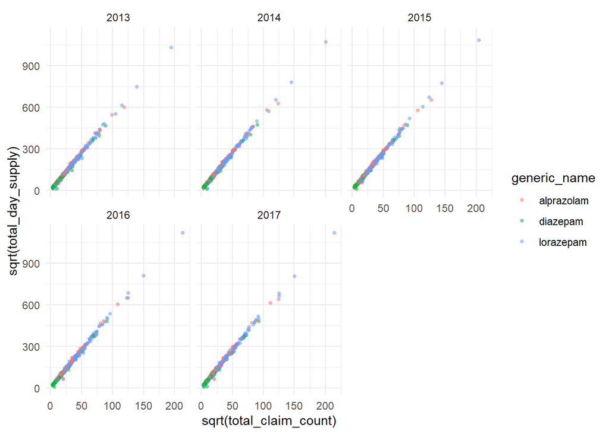

```r
death_acs_opi_coord <- death_acs_opi_pres %>%
  mutate(id = row_number()) %>%
  inner_join(ma_town_coord, by = c("city_death" = "town"))
# what to do with the benzo data?
# look at the different drugs and the features related - probably will pick one because features are correlated
benzo_pres %>%
  ggplot(aes(sqrt(total_claim_count), sqrt(total_day_supply), color = generic_name)) +
  geom_point(alpha = 0.5, size = 1) +
  facet_wrap(~ year)
```

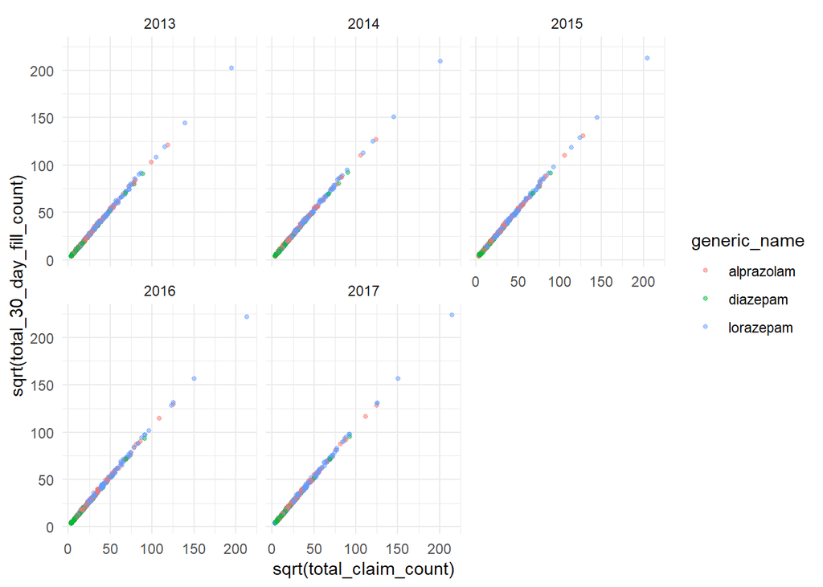

```r
benzo_pres %>%
  ggplot(aes(sqrt(total_claim_count), sqrt(total_30_day_fill_count), color = generic_name)) +
  geom_point(alpha = 0.5, size = 1) +
  facet_wrap(~ year)
```

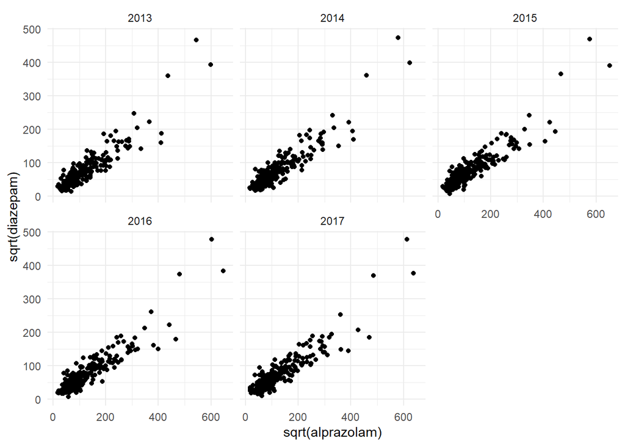

```r
benzo_tot_day_supp <- benzo_pres %>%
  select(town:year, total_day_supply) %>%
  spread(key = generic_name, value = total_day_supply)
benzo_tot_day_supp %>%
  ggplot(aes(sqrt(alprazolam), sqrt(diazepam))) +
  geom_point() +
  facet_wrap(~ year)
```

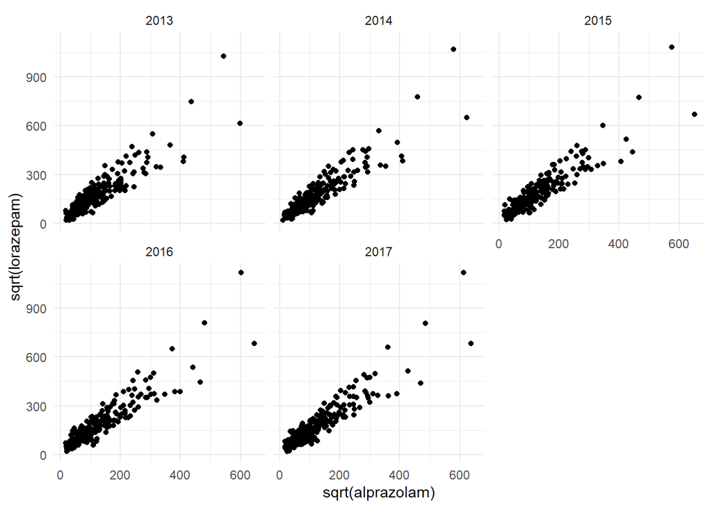

```r
benzo_tot_day_supp %>%
  ggplot(aes(sqrt(alprazolam), sqrt(lorazepam))) +
  geom_point() +
  facet_wrap(~ year)
```

```r
sapply(data.frame(sapply(benzo_tot_day_supp, is.na)), sum)
```

```
      town       year alprazolam   diazepam  lorazepam
         0          0         66        126         10
```

```r
# here replace NA with zeroes - already had to drop too many towns
length(unique(benzo_pres$town))
```

```
[1] 267
```

```r
benzo_tot_day_supp_nona <- benzo_tot_day_supp %>%
  replace(is.na(.), 0) %>%
  rename(city_death = town)
sapply(data.frame(sapply(benzo_tot_day_supp_nona, is.na)), sum)
```

```
city_death       year alprazolam   diazepam  lorazepam
         0          0          0          0          0
```

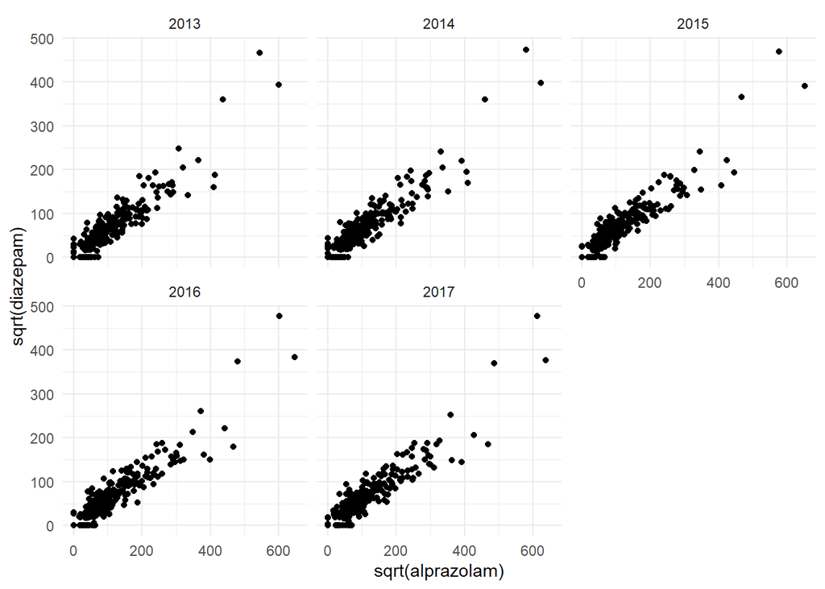

```r
benzo_tot_day_supp_nona %>%
  ggplot(aes(sqrt(alprazolam), sqrt(diazepam))) +
  geom_point() +
  facet_wrap(~ year)
```

```r
benzo_tot_day_supp_nona
```

```
# A tibble: 1,285 x 5
   city_death  year alprazolam diazepam lorazepam
   <chr>      <dbl>      <dbl>    <dbl>     <dbl>
 1 abington    2013      13567     4020     11567
 2 abington    2014      12428     3225     11173
 3 abington    2015      11241     3851     11227
 4 abington    2016       8777     1672     10919
 5 abington    2017       8384     1908     11206
 6 acton       2013       4800     4351     19803
 7 acton       2014       4572     3844     25170
 8 acton       2015       6141     3152     23847
 9 acton       2016       6411     3479     26103
10 acton       2017       6430     5038     30669
# ... with 1,275 more rows
```

```r
# all 3 of the benzos seem correlated, but may provide different enough information to be individually useful?
mod_df_count <- death_acs_opi_coord %>%
  inner_join(benzo_tot_day_supp_nona, by = c("city_death", "year")) %>%
  mutate(
    # normalize prescription counts to over 65 population:
    alprazolam_per_65_and_over = alprazolam / over_65_count,
    diazepam_per_65_and_over = diazepam / over_65_count,
    lorazepam_per_65_and_over = lorazepam / over_65_count,
    tot_benzo_count = alprazolam + diazepam + lorazepam,
    tot_benzo_per_65_and_over = tot_benzo_count / over_65_count
  ) %>%
  select(-c(alprazolam, diazepam, lorazepam, town))
colnames(mod_df_count)
```

```
 [1] "city_death"                 "year"
 [3] "death_count_next_year"      "tot_pop"
 [5] "over_65_count"              "over_65_prop"
 [7] "med_house_inc"              "mean_house_inc"
 [9] "less_than_hs_ed"            "at_or_below_pov_prop"
[11] "pop_struggling_prop"        "urb_v_rur"
[13] "town_status"                "total_claims_count_avg"
[15] "opioid_claim_count_avg"     "opioid_rate_avg"
[17] "total_claim_count_sum"      "opioid_claim_count_sum"
[19] "claim_per_65_and_over"      "opi_claim_per_65_and_over"
[21] "id"                         "x"
[23] "y"                          "alprazolam_per_65_and_over"
[25] "diazepam_per_65_and_over"   "lorazepam_per_65_and_over"
[27] "tot_benzo_count"            "tot_benzo_per_65_and_over"
```

```r
summary(mod_df_count)
```

```
  city_death             year      death_count_next_year    tot_pop
 Length:1275        Min.   :2013   Min.   :  0.000       Min.   :  1066
 Class :character   1st Qu.:2014   1st Qu.:  0.000       1st Qu.:  8029
 Mode  :character   Median :2015   Median :  2.000       Median : 15457
                    Mean   :2015   Mean   :  7.082       Mean   : 25174
                    3rd Qu.:2016   3rd Qu.:  5.000       3rd Qu.: 28349
                    Max.   :2017   Max.   :279.000       Max.   :668541
 over_65_count    over_65_prop     med_house_inc    mean_house_inc
 Min.   :  208   Min.   :0.08689   Min.   : 38910   Min.   : 50751
 1st Qu.: 1640   1st Qu.:0.16575   1st Qu.: 70220   1st Qu.: 85564
 Median : 2982   Median :0.18747   Median : 86537   Median :102035
 Mean   : 4456   Mean   :0.19959   Mean   : 91264   Mean   :112554
 3rd Qu.: 5578   3rd Qu.:0.22042   3rd Qu.:108948   3rd Qu.:128541
 Max.   :85040   Max.   :0.47370   Max.   :203027   Max.   :316352
 less_than_hs_ed   at_or_below_pov_prop pop_struggling_prop
 Min.   : 0.8855   Min.   :0.005354     Min.   :0.01064
 1st Qu.: 3.2504   1st Qu.:0.042473     1st Qu.:0.06293
 Median : 5.4056   Median :0.059790     Median :0.09148
 Mean   : 6.8199   Mean   :0.075594     Mean   :0.10257
 3rd Qu.: 8.5175   3rd Qu.:0.094964     3rd Qu.:0.13115
 Max.   :32.3361   Max.   :0.332260     Max.   :0.30487
  urb_v_rur         town_status        total_claims_count_avg
 Length:1275        Length:1275        Min.   :  63.5
 Class :character   Class :character   1st Qu.: 946.3
 Mode  :character   Mode  :character   Median :1308.0
                                       Mean   :1517.2
                                       3rd Qu.:1801.5
                                       Max.   :8922.6
 opioid_claim_count_avg opioid_rate_avg  total_claim_count_sum
 Min.   :  0.00         Min.   : 0.000   Min.   :     66
 1st Qu.: 33.01         1st Qu.: 5.450   1st Qu.:  18158
 Median : 53.17         Median : 8.107   Median :  40552
 Mean   : 67.44         Mean   : 8.683   Mean   : 126434
 3rd Qu.: 81.53         3rd Qu.:10.879   3rd Qu.: 111286
 Max.   :555.50         Max.   :69.697   Max.   :5442227
 opioid_claim_count_sum claim_per_65_and_over opi_claim_per_65_and_over
 Min.   :     0.0       Min.   :  0.0694      Min.   :0.0000
 1st Qu.:   694.5       1st Qu.:  8.3145      1st Qu.:0.3200
 Median :  1793.0       Median : 16.0581      Median :0.6469
 Mean   :  5314.7       Mean   : 20.5301      Mean   :0.8988
```

[output cut: 8 more lines]

```
 Max.   :1428.0   Max.   :-73.65   Max.   :34.24
 alprazolam_per_65_and_over diazepam_per_65_and_over
 Min.   : 0.000             Min.   : 0.0000
 1st Qu.: 1.475             1st Qu.: 0.5079
 Median : 2.899             Median : 1.1588
 Mean   : 3.955             Mean   : 1.6356
 3rd Qu.: 5.210             3rd Qu.: 2.1955
 Max.   :36.725             Max.   :17.0570
 lorazepam_per_65_and_over tot_benzo_count   tot_benzo_per_65_and_over
 Min.   : 0.000            Min.   :     15   Min.   :  0.00453
 1st Qu.: 3.328            1st Qu.:  11546   1st Qu.:  5.72759
 Median : 6.394            Median :  29082   Median : 10.80296
 Mean   : 8.337            Mean   :  75716   Mean   : 13.92804
 3rd Qu.:11.492            3rd Qu.:  78967   3rd Qu.: 19.07068
 Max.   :72.222            Max.   :1855444   Max.   :114.81013
```

```r
sapply(data.frame(sapply(mod_df_count, is.na)), sum)
```

```
                city_death                       year
                         0                          0
     death_count_next_year                    tot_pop
                         0                          0
             over_65_count               over_65_prop
                         0                          0
             med_house_inc             mean_house_inc
                         0                          0
           less_than_hs_ed       at_or_below_pov_prop
                         0                          0
       pop_struggling_prop                  urb_v_rur
                         0                          0
               town_status     total_claims_count_avg
                         0                          0
    opioid_claim_count_avg            opioid_rate_avg
                         0                          0
     total_claim_count_sum     opioid_claim_count_sum
                         0                          0
     claim_per_65_and_over  opi_claim_per_65_and_over
                         0                          0
                        id                          x
                         0                          0
                         y alprazolam_per_65_and_over
                         0                          0
  diazepam_per_65_and_over  lorazepam_per_65_and_over
                         0                          0
           tot_benzo_count  tot_benzo_per_65_and_over
                         0                          0
```

# Modeling

## Data Split

Train set: 2014-2016(2013-2015 below) Validation set: 2017 (2016 below) Test set (for final model): 2018 (2017 below)

```r
test_set <- mod_df_count %>%
  filter(year == 2017)
valid_set <- mod_df_count %>%
  filter(year == 2016)
train_set <- mod_df_count %>%
  filter(year < 2016)
train_set %>%
  count(year)
```

```
## # A tibble: 3 x 2
##    year     n
##   <dbl> <int>
## 1  2013   261
## 2  2014   254
## 3  2015   253
```

```r
mean(mod_df_count$death_count_next_year)
```

```
## [1] 7.082353
```

```r
var(mod_df_count$death_count_next_year)
```

```
## [1] 394.6015
```

```r
length(unique(mod_df_count$city_death))
```

```
## [1] 265
```

Note: Variance =/= Mean - data is overdispersed and a poisson is not appropriate - try negative binomial distribution.

## Functions

Note: Concurvity is a metric provided by mgcv to evaluate the relationship between features (generalization of linearity) - ranges from 0 (good) to 1 (bad - strong relationship with other features). Concurvity can be evaluated for a feature in relation to all others (this is provided by the call `concurvity(model, full = TRUE)`), and I will focus on the “worst-case” concurvity metric. According to the Noam Ross course on GAMs (datacamp), 0.84 is a good rule of thumb for worst-case concurvity tolerance. Concurvity can also be evaluated between individual pairs of features (with the call `concurvity(model, full = FALSE)`) - again will focus on worst-case concurvity estimate.

Simple functions to calculate RMSE error to evaluate the model performace and a function to tidy up the concurvity dataframe output by mgcv (converts to a dataframe and select out the “worst” case concurvity):

```r
# rmse error calc to evaluate models
rmse <- function(model, df) {
  rmse_error <- (df$death_count_next_year - predict(model, df, type = "response")) ^ 2 %>%
    mean() %>%
    sqrt()
  return(rmse_error)
}
# concurvity transform to pull out the worst-case relationships between features
concurvity_df <- function(model) {
  worst_conc_tbl <- concurvity(model, full = FALSE) %>%
    data.frame() %>%
    rownames_to_column("feature") %>%
    tbl_df() %>%
    mutate_if(is.numeric, round, 3) %>%
    select(feature, contains("worst"))
  return(worst_conc_tbl)
}
```

## Model building - feature selection and parameter tuning

Base model - only the required variables of: * geospatial coordinates, incorporated as an interaction term s(x, y) - centroids of the municipalities left in the dataset * population to normalize opioid overdose death counts * year

Note: `method="REML"` is a method to select the optimal smoothing parameter (to prevent overfitting and underfitting) - controls how close to the data points each individual smooth will get.

```r
base_model <- gam(
  death_count_next_year ~ s(x,y) + s(year, k = 3) + s(tot_pop),
  data = train_set, method = "REML", family = nb()
  )
summary(base_model)
```

```
##
## Family: Negative Binomial(2.275)
## Link function: log
##
## Formula:
## death_count_next_year ~ s(x, y) + s(year, k = 3) + s(tot_pop)
##
## Parametric coefficients:
##             Estimate Std. Error z value Pr(>|z|)
## (Intercept)  0.82512    0.03939   20.95   <2e-16 ***
## ---
## Signif. codes:  0 '***' 0.001 '**' 0.01 '*' 0.05 '.' 0.1 ' ' 1
##
## Approximate significance of smooth terms:
##               edf Ref.df  Chi.sq  p-value
## s(x,y)     16.174 20.914   76.63 2.81e-08 ***
## s(year)     1.001  1.002   23.43 1.31e-06 ***
## s(tot_pop)  6.924  7.996 1196.66  < 2e-16 ***
## ---
## Signif. codes:  0 '***' 0.001 '**' 0.01 '*' 0.05 '.' 0.1 ' ' 1
##
## R-sq.(adj) =  0.913   Deviance explained = 75.7%
## -REML = 1624.9  Scale est. = 1         n = 768
```

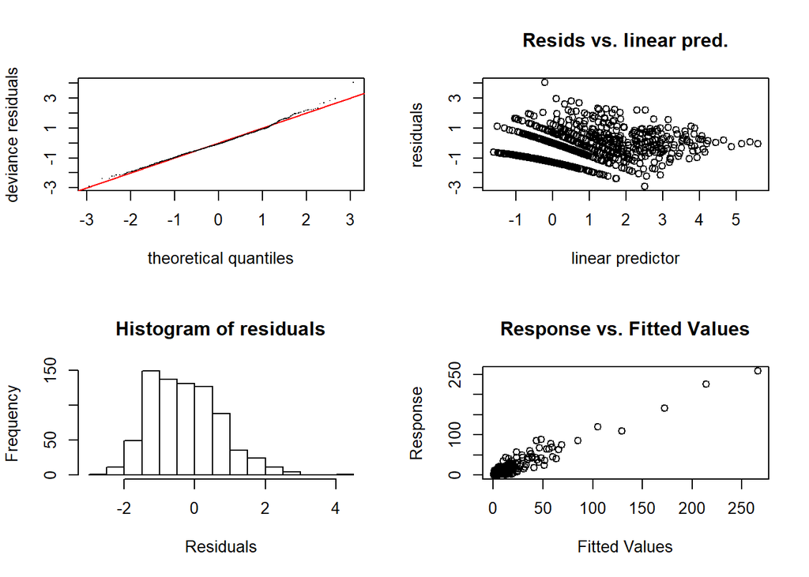

```
##
## Method: REML   Optimizer: outer newton
## full convergence after 6 iterations.
## Gradient range [-0.0003589267,0.0002175231]
## (score 1624.898 & scale 1).
## Hessian positive definite, eigenvalue range [0.0003586701,91.20615].
## Model rank =  41 / 41
##
## Basis dimension (k) checking results. Low p-value (k-index<1) may
## indicate that k is too low, especially if edf is close to k'.
##
##               k'   edf k-index p-value
## s(x,y)     29.00 16.17    0.64  <2e-16 ***
## s(year)     2.00  1.00    0.99    0.96
## s(tot_pop)  9.00  6.92    0.78  <2e-16 ***
## ---
## Signif. codes:  0 '***' 0.001 '**' 0.01 '*' 0.05 '.' 0.1 ' ' 1
```

```r
gam.check(base_model)
```

```r
concurvity(base_model)
```

```
##                  para    s(x,y)     s(year) s(tot_pop)
## worst    2.869394e-21 0.5033540 0.005057554 0.50344365
## observed 2.869394e-21 0.1307939 0.005050033 0.40590528
## estimate 2.869394e-21 0.0775063 0.004746063 0.09423382
```

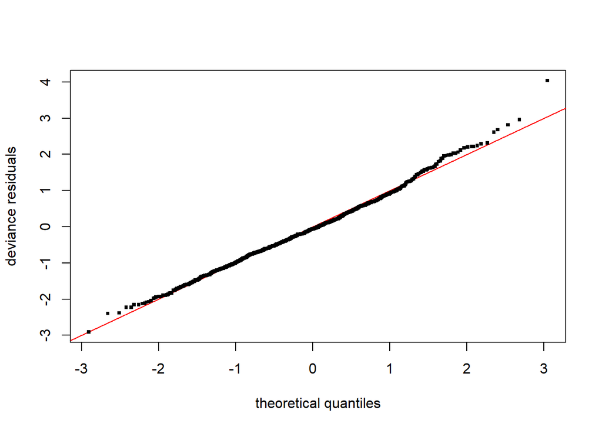

```r
qq.gam(base_model, cex = 4)
```

```r
# error on training
rmse(base_model, train_set)
```

```
## [1] 5.402927
```

```r
# error on validation
rmse(base_model, valid_set)
```

```
## [1] 8.645674
```

```r
mean(train_set$death_count_next_year)
```

```
## [1] 6.666667
```

```r
sd(train_set$death_count_next_year)
```

```
## [1] 18.62659
```

```r
mean(valid_set$death_count_next_year)
```

```
## [1] 7.637795
```

```r
sd(valid_set$death_count_next_year)
```

```
## [1] 21.96716
```

Error on training data slightly smaller than the mean, but error slightly larger than the mean for the validations set. Both smaller than the standard deviation.

Full model to get a sense of other extreme (will likely overfit the data):

```r
### all features
full_model <- gam(
    death_count_next_year ~ s(x,y) + s(year, k=3) + s(tot_pop) + s(med_house_inc) + s(mean_house_inc) + s(at_or_below_pov_prop) + s(pop_struggling_prop) + town_status + urb_v_rur + s(opioid_rate_avg) + s(less_than_hs_ed) + s(alprazolam_per_65_and_over) + s(diazepam_per_65_and_over) + s(lorazepam_per_65_and_over) + s(tot_benzo_per_65_and_over),
    data = train_set, method = "REML", family = nb(), select = TRUE
    )
summary(full_model)
```

```
##
## Family: Negative Binomial(7.878)
## Link function: log
##
## Formula:
## death_count_next_year ~ s(x, y) + s(year, k = 3) + s(tot_pop) +
##     s(med_house_inc) + s(mean_house_inc) + s(at_or_below_pov_prop) +
##     s(pop_struggling_prop) + town_status + urb_v_rur + s(opioid_rate_avg) +
##     s(less_than_hs_ed) + s(alprazolam_per_65_and_over) + s(diazepam_per_65_and_over) +
##     s(lorazepam_per_65_and_over) + s(tot_benzo_per_65_and_over)
##
## Parametric coefficients:
##                      Estimate Std. Error z value Pr(>|z|)
## (Intercept)           0.65197    0.05108  12.764   <2e-16 ***
## town_statusshrunk     0.30337    0.19253   1.576   0.1151
## town_statusuncertain  0.34967    0.17434   2.006   0.0449 *
## urb_v_rururban       -0.29291    0.20331  -1.441   0.1497
## ---
## Signif. codes:  0 '***' 0.001 '**' 0.01 '*' 0.05 '.' 0.1 ' ' 1
##
## Approximate significance of smooth terms:
##                                     edf Ref.df  Chi.sq  p-value
## s(x,y)                        1.459e+01     29 117.024  < 2e-16 ***
## s(year)                       9.773e-01      2  41.761 4.85e-11 ***
## s(tot_pop)                    6.874e+00      9 296.480  < 2e-16 ***
## s(med_house_inc)              4.583e+00      9  25.608 3.80e-07 ***
## s(mean_house_inc)             5.275e+00      9  37.598 6.70e-10 ***
## s(at_or_below_pov_prop)       2.418e+00      9   6.571 0.020820 *
## s(pop_struggling_prop)        3.991e+00      9  14.643 0.000754 ***
## s(opioid_rate_avg)            3.923e+00      9  18.261 0.000239 ***
## s(less_than_hs_ed)            3.164e+00      9  15.260 0.000125 ***
## s(alprazolam_per_65_and_over) 2.209e+00      9  10.004 0.001402 **
## s(diazepam_per_65_and_over)   6.199e-01      9   1.534 0.095020 .
## s(lorazepam_per_65_and_over)  5.424e+00      9  24.205 1.62e-05 ***
## s(tot_benzo_per_65_and_over)  6.816e-04      9   0.000 0.256872
## ---
## Signif. codes:  0 '***' 0.001 '**' 0.01 '*' 0.05 '.' 0.1 ' ' 1
##
## R-sq.(adj) =  0.956   Deviance explained = 87.9%
## -REML = 1517.9  Scale est. = 1         n = 768
```

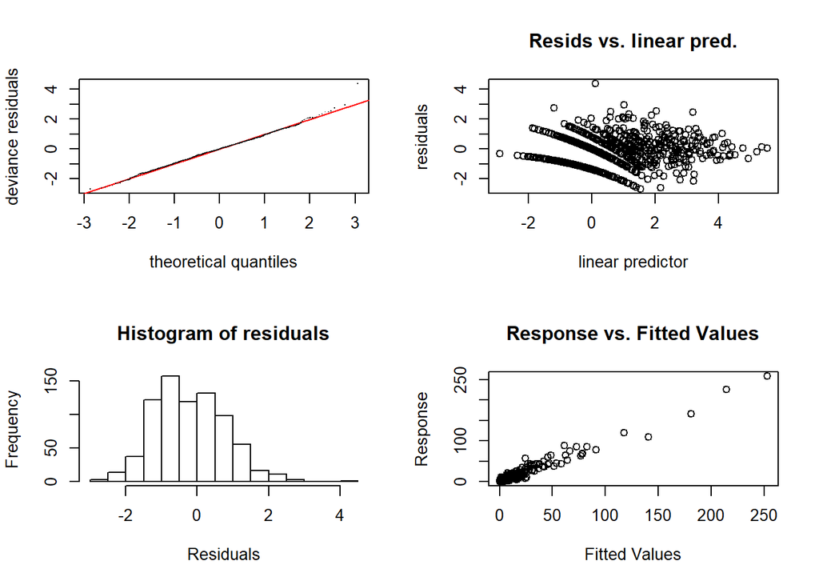

```
##
## Method: REML   Optimizer: outer newton
## full convergence after 12 iterations.
## Gradient range [-0.0001428146,0.0001230164]
## (score 1517.908 & scale 1).
## Hessian positive definite, eigenvalue range [8.730545e-07,26.01711].
## Model rank =  134 / 134
##
## Basis dimension (k) checking results. Low p-value (k-index<1) may
## indicate that k is too low, especially if edf is close to k'.
##
##                                     k'      edf k-index p-value
## s(x,y)                        2.90e+01 1.46e+01    0.81  <2e-16 ***
## s(year)                       2.00e+00 9.77e-01    0.99   0.835
## s(tot_pop)                    9.00e+00 6.87e+00    0.83  <2e-16 ***
## s(med_house_inc)              9.00e+00 4.58e+00    0.85   0.005 **
## s(mean_house_inc)             9.00e+00 5.28e+00    0.84   0.005 **
## s(at_or_below_pov_prop)       9.00e+00 2.42e+00    0.81  <2e-16 ***
## s(pop_struggling_prop)        9.00e+00 3.99e+00    0.82  <2e-16 ***
## s(opioid_rate_avg)            9.00e+00 3.92e+00    0.98   0.705
## s(less_than_hs_ed)            9.00e+00 3.16e+00    0.83  <2e-16 ***
## s(alprazolam_per_65_and_over) 9.00e+00 2.21e+00    0.88   0.010 **
## s(diazepam_per_65_and_over)   9.00e+00 6.20e-01    0.92   0.115
## s(lorazepam_per_65_and_over)  9.00e+00 5.42e+00    0.95   0.380
## s(tot_benzo_per_65_and_over)  9.00e+00 6.82e-04    0.99   0.880
## ---
## Signif. codes:  0 '***' 0.001 '**' 0.01 '*' 0.05 '.' 0.1 ' ' 1
```

```r
gam.check(full_model)
```

```r
concurvity(full_model)
```

```
##               para    s(x,y)    s(year) s(tot_pop) s(med_house_inc)
## worst    0.8043803 0.8901247 0.09750532  0.9676531        0.9925054
## observed 0.8043803 0.7171183 0.09635786  0.8739724        0.9203671
## estimate 0.8043803 0.4991810 0.09214063  0.6354924        0.9513265
##          s(mean_house_inc) s(at_or_below_pov_prop) s(pop_struggling_prop)
## worst            0.9922517               0.9446710              0.9183833
## observed         0.9607983               0.7201526              0.7130976
## estimate         0.9427858               0.7840649              0.8662636
##          s(opioid_rate_avg) s(less_than_hs_ed)
## worst             0.5019621          0.9379660
## observed          0.4400296          0.8071582
## estimate          0.3079763          0.8839784
##          s(alprazolam_per_65_and_over) s(diazepam_per_65_and_over)
## worst                        1.0000000                   1.0000000
## observed                     0.9856141                   1.0000000
## estimate                     0.9554668                   0.9263938
##          s(lorazepam_per_65_and_over) s(tot_benzo_per_65_and_over)
## worst                       1.0000000                    1.0000000
## observed                    0.9407968                    0.9938819
## estimate                    0.9779626                    0.9874420
```

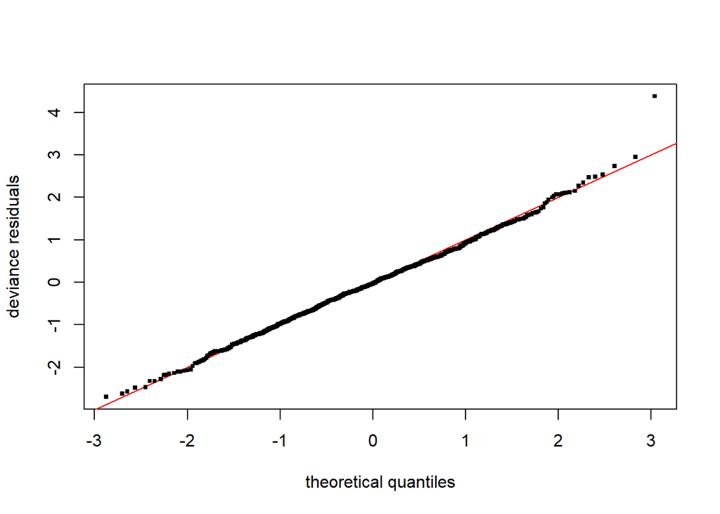

```r
qq.gam(full_model, cex = 4)
```

```r
# error on training
rmse(full_model, train_set)
```

```
## [1] 3.775817
```

```r
# error on validation
rmse(full_model, valid_set)
```

```
## [1] 8.461238
```

Notes:

GAM Summary: * tot_benzo_per_65_and_over - shrunken coefficient and not significant * diazepam_per_65_and_over - not significant * urb_v_rururban - not significant

GAM check: * many features have significant p-value - indicator that more basis functions may be needed * will keep running gam check, but will largely ignore the basis-function stat test until the list of features in the model is finalized

Concurvity: * Concurvity very high (0.9-1 for most features) - definitely need to remove features

RMSE Error: * both train and validation error lower than the base model, but that’s not too surprising

Concurvity check on pairs of individual features:

```r
full_model_conc <- concurvity_df(full_model)
# result:
full_model_conc
```

```
## # A tibble: 14 x 15
##    feature worst.para worst.s.x.y. worst.s.year. worst.s.tot_pop.
##    <chr>        <dbl>        <dbl>         <dbl>            <dbl>
##  1 para             1        0             0                0
##  2 s(x,y)           0        1             0.001            0.503
##  3 s(year)          0        0.001         1                0.004
##  4 s(tot_~          0        0.503         0.004            1
##  5 s(med_~          0        0.559         0.001            0.202
##  6 s(mean~          0        0.52          0.001            0.19
##  7 s(at_o~          0        0.357         0                0.552
##  8 s(pop_~          0        0.423         0.001            0.263
##  9 s(opio~          0        0.172         0.026            0.195
## 10 s(less~          0        0.398         0                0.444
## 11 s(alpr~          0        0.3           0.01             0.2
## 12 s(diaz~          0        0.175         0.008            0.172
## 13 s(lora~          0        0.203         0.01             0.155
## 14 s(tot_~          0        0.239         0.015            0.192
## # ... with 10 more variables: worst.s.med_house_inc. <dbl>,
## #   worst.s.mean_house_inc. <dbl>, worst.s.at_or_below_pov_prop. <dbl>,
## #   worst.s.pop_struggling_prop. <dbl>, worst.s.opioid_rate_avg. <dbl>,
## #   worst.s.less_than_hs_ed. <dbl>,
## #   worst.s.alprazolam_per_65_and_over. <dbl>,
## #   worst.s.diazepam_per_65_and_over. <dbl>,
## #   worst.s.lorazepam_per_65_and_over. <dbl>,
## #   worst.s.tot_benzo_per_65_and_over. <dbl>
```

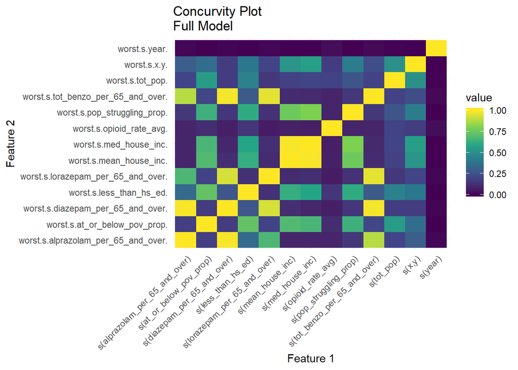

```r
# heatmap plot
full_model_conc <- full_model_conc %>%
  filter(feature != "para") %>%
  select(-worst.para) %>%
  gather(key="feature2", value="value", -feature) %>%
  ggplot(aes(feature, feature2, fill=value)) +
  geom_raster() +
  scale_fill_viridis_c() +
  theme(axis.text.x = element_text(angle=45, hjust=1)) +
  ggtitle("Concurvity Plot\nFull Model") +
  xlab("Feature 1") +
  ylab("Feature 2")
full_model_conc
```

```r
# save for blog:
#save_plot(filename = "../../../figures/tidy_figures/full_model_concurvity.png", full_model_conc, base_height = 6, base_width = 8)
```

Concurvity 0 (best) - 1 (worst)

- diazepam and tot_benzo were not predictive and also have very high concurvity with several features - good candidates for removal
- median and mean income are basically the same feature - will have to pick one

Q: Does it matter if the data is scaled? Should not because a GAM is a nonlinear type of modeling, but worth it to check.

```r
# scale training data:
train_set_scaled <- train_set %>%
  select(-c(year:death_count_next_year, x:y)) %>%
  mutate_if(is.numeric, scale) %>%
    bind_cols(
      train_set %>%
        select(year:death_count_next_year, x:y)
    )
colnames(train_set_scaled)
```

```
##  [1] "city_death"                 "tot_pop"
##  [3] "over_65_count"              "over_65_prop"
##  [5] "med_house_inc"              "mean_house_inc"
##  [7] "less_than_hs_ed"            "at_or_below_pov_prop"
##  [9] "pop_struggling_prop"        "urb_v_rur"
## [11] "town_status"                "total_claims_count_avg"
## [13] "opioid_claim_count_avg"     "opioid_rate_avg"
## [15] "total_claim_count_sum"      "opioid_claim_count_sum"
## [17] "claim_per_65_and_over"      "opi_claim_per_65_and_over"
## [19] "id"                         "alprazolam_per_65_and_over"
## [21] "diazepam_per_65_and_over"   "lorazepam_per_65_and_over"
## [23] "tot_benzo_count"            "tot_benzo_per_65_and_over"
## [25] "year"                       "death_count_next_year"
## [27] "x"                          "y"
```

```r
full_model_scaled <- gam(
    death_count_next_year ~ s(x,y) + s(year, k=3) + s(tot_pop) + s(med_house_inc) + s(mean_house_inc) + s(at_or_below_pov_prop) + s(pop_struggling_prop) + town_status + urb_v_rur + s(opioid_rate_avg) + s(less_than_hs_ed) + s(alprazolam_per_65_and_over) + s(diazepam_per_65_and_over) + s(lorazepam_per_65_and_over) + s(tot_benzo_per_65_and_over),
    data = train_set_scaled, method = "REML", family = nb(), select = TRUE
    )
summary(full_model_scaled)
```

```
##
## Family: Negative Binomial(7.878)
## Link function: log
##
## Formula:
## death_count_next_year ~ s(x, y) + s(year, k = 3) + s(tot_pop) +
##     s(med_house_inc) + s(mean_house_inc) + s(at_or_below_pov_prop) +
##     s(pop_struggling_prop) + town_status + urb_v_rur + s(opioid_rate_avg) +
##     s(less_than_hs_ed) + s(alprazolam_per_65_and_over) + s(diazepam_per_65_and_over) +
##     s(lorazepam_per_65_and_over) + s(tot_benzo_per_65_and_over)
##
## Parametric coefficients:
##                      Estimate Std. Error z value Pr(>|z|)
## (Intercept)           0.65197    0.05108  12.764   <2e-16 ***
## town_statusshrunk     0.30337    0.19253   1.576   0.1151
## town_statusuncertain  0.34967    0.17434   2.006   0.0449 *
## urb_v_rururban       -0.29291    0.20331  -1.441   0.1497
## ---
## Signif. codes:  0 '***' 0.001 '**' 0.01 '*' 0.05 '.' 0.1 ' ' 1
##
## Approximate significance of smooth terms:
##                                     edf Ref.df  Chi.sq  p-value
## s(x,y)                        1.459e+01     29 117.024  < 2e-16 ***
## s(year)                       9.773e-01      2  41.761 4.85e-11 ***
## s(tot_pop)                    6.874e+00      9 296.480  < 2e-16 ***
## s(med_house_inc)              4.583e+00      9  25.608 3.80e-07 ***
## s(mean_house_inc)             5.275e+00      9  37.598 6.70e-10 ***
## s(at_or_below_pov_prop)       2.418e+00      9   6.571 0.020820 *
## s(pop_struggling_prop)        3.991e+00      9  14.643 0.000754 ***
## s(opioid_rate_avg)            3.923e+00      9  18.261 0.000239 ***
## s(less_than_hs_ed)            3.164e+00      9  15.260 0.000125 ***
## s(alprazolam_per_65_and_over) 2.209e+00      9  10.004 0.001402 **
## s(diazepam_per_65_and_over)   6.199e-01      9   1.534 0.095020 .
## s(lorazepam_per_65_and_over)  5.424e+00      9  24.205 1.62e-05 ***
## s(tot_benzo_per_65_and_over)  6.816e-04      9   0.000 0.256872
## ---
## Signif. codes:  0 '***' 0.001 '**' 0.01 '*' 0.05 '.' 0.1 ' ' 1
##
## R-sq.(adj) =  0.956   Deviance explained = 87.9%
## -REML = 1517.9  Scale est. = 1         n = 768
```

```r
summary(full_model)
```

```
##
## Family: Negative Binomial(7.878)
## Link function: log
##
## Formula:
## death_count_next_year ~ s(x, y) + s(year, k = 3) + s(tot_pop) +
##     s(med_house_inc) + s(mean_house_inc) + s(at_or_below_pov_prop) +
##     s(pop_struggling_prop) + town_status + urb_v_rur + s(opioid_rate_avg) +
##     s(less_than_hs_ed) + s(alprazolam_per_65_and_over) + s(diazepam_per_65_and_over) +
##     s(lorazepam_per_65_and_over) + s(tot_benzo_per_65_and_over)
##
## Parametric coefficients:
##                      Estimate Std. Error z value Pr(>|z|)
## (Intercept)           0.65197    0.05108  12.764   <2e-16 ***
## town_statusshrunk     0.30337    0.19253   1.576   0.1151
## town_statusuncertain  0.34967    0.17434   2.006   0.0449 *
## urb_v_rururban       -0.29291    0.20331  -1.441   0.1497
## ---
## Signif. codes:  0 '***' 0.001 '**' 0.01 '*' 0.05 '.' 0.1 ' ' 1
##
## Approximate significance of smooth terms:
##                                     edf Ref.df  Chi.sq  p-value
## s(x,y)                        1.459e+01     29 117.024  < 2e-16 ***
## s(year)                       9.773e-01      2  41.761 4.85e-11 ***
## s(tot_pop)                    6.874e+00      9 296.480  < 2e-16 ***
## s(med_house_inc)              4.583e+00      9  25.608 3.80e-07 ***
## s(mean_house_inc)             5.275e+00      9  37.598 6.70e-10 ***
## s(at_or_below_pov_prop)       2.418e+00      9   6.571 0.020820 *
## s(pop_struggling_prop)        3.991e+00      9  14.643 0.000754 ***
## s(opioid_rate_avg)            3.923e+00      9  18.261 0.000239 ***
## s(less_than_hs_ed)            3.164e+00      9  15.260 0.000125 ***
## s(alprazolam_per_65_and_over) 2.209e+00      9  10.004 0.001402 **
## s(diazepam_per_65_and_over)   6.199e-01      9   1.534 0.095020 .
## s(lorazepam_per_65_and_over)  5.424e+00      9  24.205 1.62e-05 ***
## s(tot_benzo_per_65_and_over)  6.816e-04      9   0.000 0.256872
## ---
## Signif. codes:  0 '***' 0.001 '**' 0.01 '*' 0.05 '.' 0.1 ' ' 1
##
## R-sq.(adj) =  0.956   Deviance explained = 87.9%
## -REML = 1517.9  Scale est. = 1         n = 768
```

```r
# error on training
rmse(full_model_scaled, train_set_scaled)
```

```
## [1] 3.775817
```

Scaling and not scaling outputs the same model - good. Don’t need to scale, makes for a simpler workflow.

Now start removing features. For this version, remove: * med_house_inc * tot_benzo_per_65_and_over

```r
full_model_sub1 <- gam(
    death_count_next_year ~ s(x,y) + s(year, k=3) + s(tot_pop) + s(mean_house_inc) + s(at_or_below_pov_prop) + s(pop_struggling_prop) + town_status + urb_v_rur + s(opioid_rate_avg) + s(less_than_hs_ed) + s(alprazolam_per_65_and_over) + s(diazepam_per_65_and_over) + s(lorazepam_per_65_and_over),
    data = train_set, method = "REML", family = nb(), select = TRUE
    )
summary(full_model_sub1)
```

```
##
## Family: Negative Binomial(6.573)
## Link function: log
##
## Formula:
## death_count_next_year ~ s(x, y) + s(year, k = 3) + s(tot_pop) +
##     s(mean_house_inc) + s(at_or_below_pov_prop) + s(pop_struggling_prop) +
##     town_status + urb_v_rur + s(opioid_rate_avg) + s(less_than_hs_ed) +
##     s(alprazolam_per_65_and_over) + s(diazepam_per_65_and_over) +
##     s(lorazepam_per_65_and_over)
##
## Parametric coefficients:
##                      Estimate Std. Error z value Pr(>|z|)
## (Intercept)            0.6619     0.0511  12.953   <2e-16 ***
## town_statusshrunk      0.2547     0.1885   1.351   0.1767
## town_statusuncertain   0.3655     0.1656   2.207   0.0273 *
## urb_v_rururban        -0.2348     0.2108  -1.114   0.2655
## ---
## Signif. codes:  0 '***' 0.001 '**' 0.01 '*' 0.05 '.' 0.1 ' ' 1
##
## Approximate significance of smooth terms:
##                                   edf Ref.df  Chi.sq  p-value
## s(x,y)                        12.4291     29 106.454  < 2e-16 ***
## s(year)                        0.9755      2  38.844 2.26e-10 ***
## s(tot_pop)                     6.8710      9 295.779  < 2e-16 ***
## s(mean_house_inc)              6.2307      9  58.406 2.19e-13 ***
## s(at_or_below_pov_prop)        1.8486      9   4.149 0.058140 .
## s(pop_struggling_prop)         4.6235      9  21.393 2.93e-05 ***
## s(opioid_rate_avg)             4.0905      9  20.275 0.000104 ***
## s(less_than_hs_ed)             2.5514      9  11.564 0.000718 ***
## s(alprazolam_per_65_and_over)  2.0496      9   7.801 0.005272 **
## s(diazepam_per_65_and_over)    0.6218      9   1.541 0.096946 .
## s(lorazepam_per_65_and_over)   4.6396      9  19.232 0.000102 ***
## ---
## Signif. codes:  0 '***' 0.001 '**' 0.01 '*' 0.05 '.' 0.1 ' ' 1
##
## R-sq.(adj) =  0.951   Deviance explained = 86.8%
## -REML =   1525  Scale est. = 1         n = 768
```

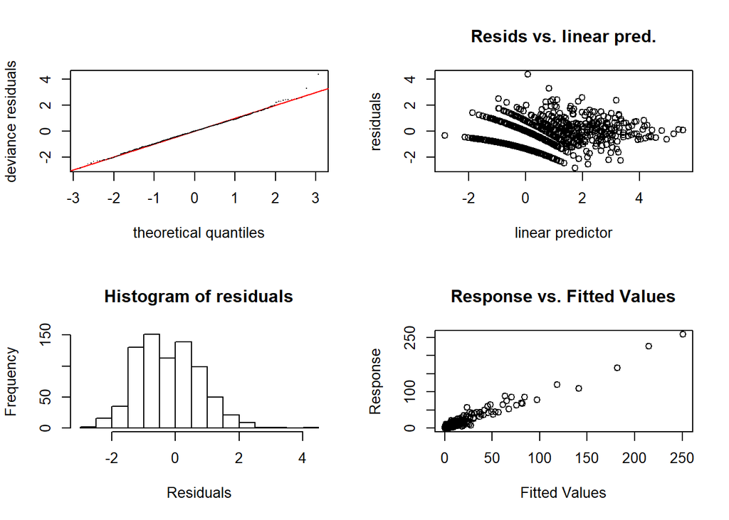

```
##
## Method: REML   Optimizer: outer newton
## full convergence after 18 iterations.
## Gradient range [-0.0004877127,0.0002431032]
## (score 1524.952 & scale 1).
## eigenvalue range [-7.266013e-06,32.25311].
## Model rank =  116 / 116
##
## Basis dimension (k) checking results. Low p-value (k-index<1) may
## indicate that k is too low, especially if edf is close to k'.
##
##                                   k'    edf k-index p-value
## s(x,y)                        29.000 12.429    0.78  <2e-16 ***
## s(year)                        2.000  0.976    0.99    0.82
## s(tot_pop)                     9.000  6.871    0.83  <2e-16 ***
## s(mean_house_inc)              9.000  6.231    0.81  <2e-16 ***
## s(at_or_below_pov_prop)        9.000  1.849    0.78  <2e-16 ***
## s(pop_struggling_prop)         9.000  4.623    0.80  <2e-16 ***
## s(opioid_rate_avg)             9.000  4.090    0.97    0.64
## s(less_than_hs_ed)             9.000  2.551    0.80  <2e-16 ***
## s(alprazolam_per_65_and_over)  9.000  2.050    0.88    0.01 **
## s(diazepam_per_65_and_over)    9.000  0.622    0.90    0.08 .
## s(lorazepam_per_65_and_over)   9.000  4.640    0.94    0.32
## ---
## Signif. codes:  0 '***' 0.001 '**' 0.01 '*' 0.05 '.' 0.1 ' ' 1
```

```r
gam.check(full_model_sub1)
```

```r
concurvity(full_model_sub1)
```

```
##               para    s(x,y)    s(year) s(tot_pop) s(mean_house_inc)
## worst    0.7972782 0.8660716 0.08479216  0.9667017         0.9342450
## observed 0.7972782 0.6831067 0.08398320  0.8494096         0.8992046
## estimate 0.7972782 0.4471575 0.07971311  0.6131828         0.7519574
##          s(at_or_below_pov_prop) s(pop_struggling_prop) s(opioid_rate_avg)
## worst                  0.9393154              0.9101353          0.4705423
## observed               0.7068064              0.6638222          0.4028014
## estimate               0.7686501              0.8473952          0.2558302
##          s(less_than_hs_ed) s(alprazolam_per_65_and_over)
## worst             0.9317136                     0.9969328
## observed          0.8231220                     0.8180054
## estimate          0.8745801                     0.7575212
##          s(diazepam_per_65_and_over) s(lorazepam_per_65_and_over)
## worst                      0.9972925                    0.9676578
## observed                   0.7982396                    0.7480433
## estimate                   0.8001251                    0.8337216
```

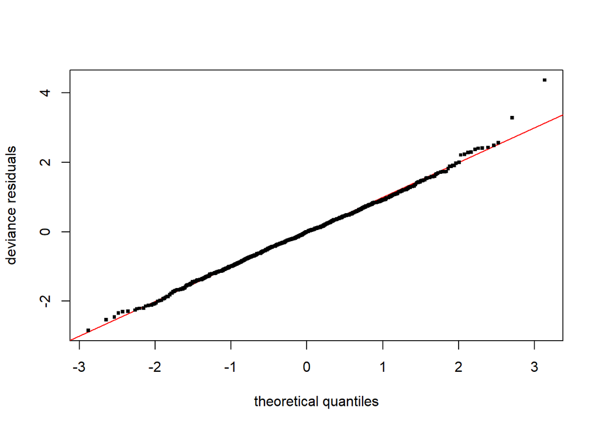

```r
qq.gam(full_model_sub1, cex = 4)
```

```r
# error on training
rmse(full_model_sub1, train_set)
```

```
## [1] 3.998305
```

```r
# error on validation
rmse(full_model_sub1, valid_set)
```

```
## [1] 8.425797
```

Notes:

GAM Summary: * now at_or_below_pov_prop no longer significant * diazepam_per_65_and_over and urb_v_rururban still not significant

GAM check: * still ignoring this mostly

Concurvity: * Concurvity still high, but most have gone down at least a little bit

RMSE Error: * train error higher * validation error slightly lower (may not be meaningful), could be sign I’m not overfitting as much as full model

Individual feature concurvity check:

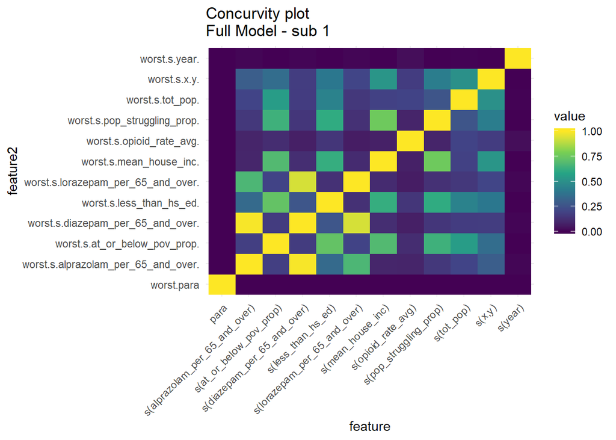

```r
full_model_sub1_conc <- concurvity_df(full_model_sub1)
full_model_sub1_conc %>%
  gather(key="feature2", value="value", -feature) %>%
  ggplot(aes(feature, feature2, fill=value)) +
  geom_raster() +
  scale_fill_viridis_c() +
  theme(axis.text.x = element_text(angle=45, hjust=1)) +
  ggtitle("Concurvity plot\nFull Model - sub 1")
```

```r
full_model_sub1_conc %>%
  select(feature, contains("per_65_and_over"))
```

```
## # A tibble: 12 x 4
##    feature      worst.s.alprazolam~ worst.s.diazepam_p~ worst.s.lorazepam_~
##    <chr>                      <dbl>               <dbl>               <dbl>
##  1 para                       0                   0                   0
##  2 s(x,y)                     0.3                 0.175               0.203
##  3 s(year)                    0.01                0.008               0.01
##  4 s(tot_pop)                 0.2                 0.172               0.155
##  5 s(mean_hous~               0.092               0.121               0.111
##  6 s(at_or_bel~               0.18                0.169               0.197
##  7 s(pop_strug~               0.156               0.15                0.132
##  8 s(opioid_ra~               0.09                0.074               0.066
##  9 s(less_than~               0.347               0.269               0.132
## 10 s(alprazola~               1                   0.99                0.669
## 11 s(diazepam_~               0.99                1                   0.933
## 12 s(lorazepam~               0.669               0.933               1
```

Diazepam is not very predictive (p-val not sig) and has high concurvity with more predictive features - remove.

Sub 2 - take out diazepam term:

```r
full_model_sub2 <- gam(
    death_count_next_year ~ s(x,y) + s(year, k=3) + s(tot_pop) + s(mean_house_inc) + s(at_or_below_pov_prop) + s(pop_struggling_prop) + town_status + urb_v_rur + s(opioid_rate_avg) + s(less_than_hs_ed) + s(alprazolam_per_65_and_over) + s(lorazepam_per_65_and_over),
    data = train_set, method = "REML", family = nb(), select = TRUE
    )
summary(full_model_sub2)
```

```
##
## Family: Negative Binomial(6.67)
## Link function: log
##
## Formula:
## death_count_next_year ~ s(x, y) + s(year, k = 3) + s(tot_pop) +
##     s(mean_house_inc) + s(at_or_below_pov_prop) + s(pop_struggling_prop) +
##     town_status + urb_v_rur + s(opioid_rate_avg) + s(less_than_hs_ed) +
##     s(alprazolam_per_65_and_over) + s(lorazepam_per_65_and_over)
##
## Parametric coefficients:
##                      Estimate Std. Error z value Pr(>|z|)
## (Intercept)           0.65497    0.05122  12.788   <2e-16 ***
## town_statusshrunk     0.28803    0.18793   1.533   0.1254
## town_statusuncertain  0.38799    0.16471   2.356   0.0185 *
## urb_v_rururban       -0.23219    0.21284  -1.091   0.2753
## ---
## Signif. codes:  0 '***' 0.001 '**' 0.01 '*' 0.05 '.' 0.1 ' ' 1
##
## Approximate significance of smooth terms:
##                                  edf Ref.df  Chi.sq  p-value
## s(x,y)                        12.548     29 107.139  < 2e-16 ***
## s(year)                        0.976      2  40.010 1.27e-10 ***
## s(tot_pop)                     7.011      9 303.563  < 2e-16 ***
## s(mean_house_inc)              6.200      9  56.451 6.43e-13 ***
## s(at_or_below_pov_prop)        1.839      9   4.028 0.062959 .
## s(pop_struggling_prop)         4.547      9  20.818 3.70e-05 ***
## s(opioid_rate_avg)             4.081      9  20.011 0.000119 ***
## s(less_than_hs_ed)             2.382      9  10.578 0.001082 **
## s(alprazolam_per_65_and_over)  2.108      9   7.826 0.006526 **
## s(lorazepam_per_65_and_over)   5.356      9  20.791 0.000134 ***
## ---
## Signif. codes:  0 '***' 0.001 '**' 0.01 '*' 0.05 '.' 0.1 ' ' 1
##
## R-sq.(adj) =   0.95   Deviance explained = 86.8%
## -REML = 1525.2  Scale est. = 1         n = 768
```

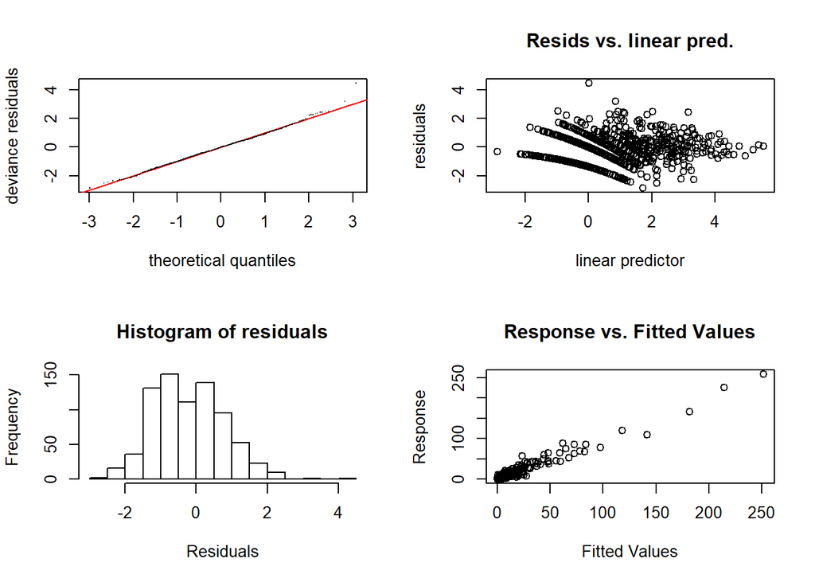

```
##
## Method: REML   Optimizer: outer newton
## full convergence after 19 iterations.
## Gradient range [-4.239513e-05,1.642815e-06]
## (score 1525.179 & scale 1).
## eigenvalue range [-1.64276e-06,31.63454].
## Model rank =  107 / 107
##
## Basis dimension (k) checking results. Low p-value (k-index<1) may
## indicate that k is too low, especially if edf is close to k'.
##
##                                   k'    edf k-index p-value
## s(x,y)                        29.000 12.548    0.79  <2e-16 ***
## s(year)                        2.000  0.976    0.99   0.810
## s(tot_pop)                     9.000  7.011    0.83  <2e-16 ***
## s(mean_house_inc)              9.000  6.200    0.81  <2e-16 ***
## s(at_or_below_pov_prop)        9.000  1.839    0.79  <2e-16 ***
## s(pop_struggling_prop)         9.000  4.547    0.80  <2e-16 ***
## s(opioid_rate_avg)             9.000  4.081    0.97   0.615
## s(less_than_hs_ed)             9.000  2.382    0.80  <2e-16 ***
## s(alprazolam_per_65_and_over)  9.000  2.108    0.88   0.005 **
## s(lorazepam_per_65_and_over)   9.000  5.356    0.94   0.365
## ---
## Signif. codes:  0 '***' 0.001 '**' 0.01 '*' 0.05 '.' 0.1 ' ' 1
```

```r
gam.check(full_model_sub2)
```

```r
concurvity(full_model_sub2)
```

```
##               para    s(x,y)    s(year) s(tot_pop) s(mean_house_inc)
## worst    0.7908477 0.8655578 0.07097704  0.9653936         0.9324474
## observed 0.7908477 0.6752159 0.06833767  0.8403280         0.8972868
## estimate 0.7908477 0.4319624 0.06485085  0.6032266         0.7446151
##          s(at_or_below_pov_prop) s(pop_struggling_prop) s(opioid_rate_avg)
## worst                  0.9382080              0.9051948          0.4427540
## observed               0.7056688              0.6655199          0.3761391
## estimate               0.7615462              0.8431381          0.2466818
##          s(less_than_hs_ed) s(alprazolam_per_65_and_over)
## worst             0.9292415                     0.8299011
## observed          0.8306705                     0.7658997
## estimate          0.8696079                     0.6159779
##          s(lorazepam_per_65_and_over)
## worst                       0.8422445
## observed                    0.4961261
## estimate                    0.6342773
```

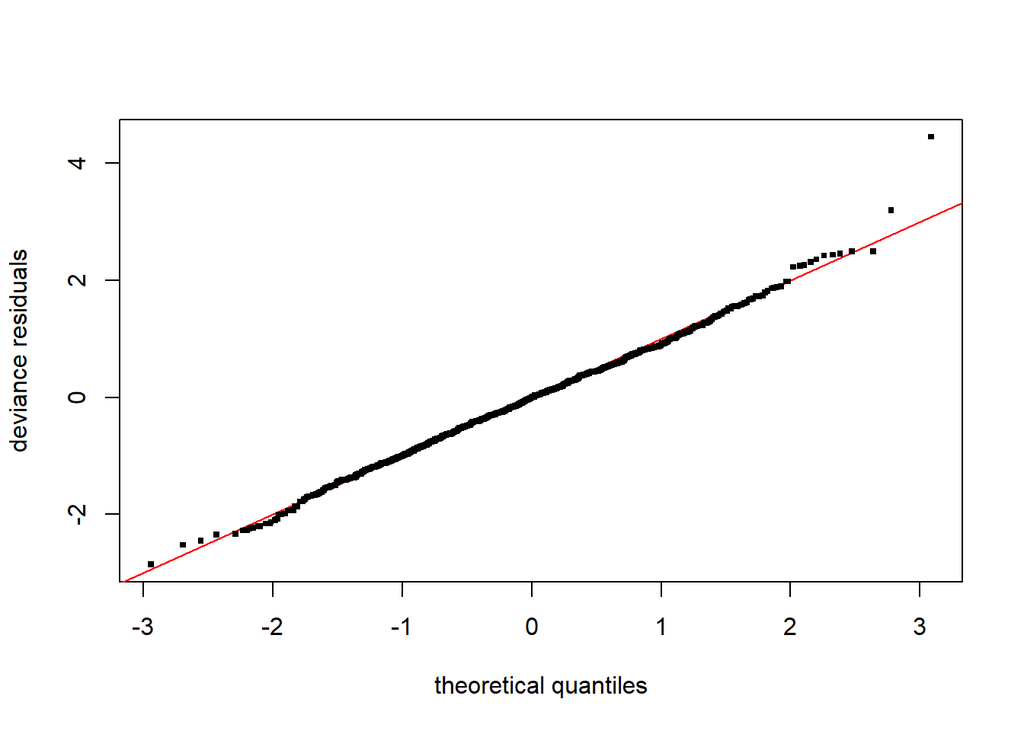

```r
qq.gam(full_model_sub2, cex = 4)
```

```r
# error on training
rmse(full_model_sub2, train_set)
```

```
## [1] 4.005698
```

```r
# error on validation
rmse(full_model_sub2, valid_set)
```

```
## [1] 8.401119
```

Notes:

GAM Summary: * at_or_below_pov_prop and urb_v_rururban still not significant

GAM check: * still ignoring this mostly

Concurvity: * lorazepam and alprazolam concurvities below/close to “removal” threshold of 0.84 now

RMSE Error: * training error about the same as previous iteration (sub1) * validation error slightly less than previous iteration (sub1) - but almost the same

Individual feature concurvity check:

- the 2 poverty metrics (at_or_below_pov_prop, pop_struggling_prop) are good candidates for removing one of them to reduce concurvity further

```r
full_model_sub2_conc <- concurvity_df(full_model_sub2)
full_model_sub2_conc %>%
  select(feature, contains("prop")) %>%
  arrange(desc(worst.s.at_or_below_pov_prop.))
```

```
## # A tibble: 11 x 3
##    feature                worst.s.at_or_below_pov_~ worst.s.pop_struggling~
##    <chr>                                      <dbl>                   <dbl>
##  1 s(at_or_below_pov_pro~                     1                       0.641
##  2 s(less_than_hs_ed)                         0.73                    0.616
##  3 s(mean_house_inc)                          0.683                   0.76
##  4 s(pop_struggling_prop)                     0.641                   1
##  5 s(tot_pop)                                 0.552                   0.263
##  6 s(x,y)                                     0.357                   0.423
##  7 s(lorazepam_per_65_an~                     0.197                   0.132
##  8 s(alprazolam_per_65_a~                     0.18                    0.156
##  9 s(opioid_rate_avg)                         0.116                   0.09
## 10 para                                       0                       0
## 11 s(year)                                    0                       0.001
```

```r
# sum of these individual concurvity values:
full_model_sub2_conc %>%
  select(contains("prop")) %>%
  summarize_all(sum)
```

```
## # A tibble: 1 x 2
##   worst.s.at_or_below_pov_prop. worst.s.pop_struggling_prop.
##                           <dbl>                        <dbl>
## 1                          4.46                         4.08
```

`at_or_below_pov_prop` has a slightly higher total concurvity with the other features in the model - try removing it first.

```r
full_model_sub3 <- gam(
    death_count_next_year ~ s(x,y) + s(year, k=3) + s(tot_pop) + s(mean_house_inc) + s(pop_struggling_prop) + town_status + urb_v_rur + s(opioid_rate_avg) + s(less_than_hs_ed) + s(alprazolam_per_65_and_over) + s(lorazepam_per_65_and_over),
    data = train_set, method = "REML", family = nb(), select = TRUE
    )
summary(full_model_sub3)
```

```
##
## Family: Negative Binomial(6.392)
## Link function: log
##
## Formula:
## death_count_next_year ~ s(x, y) + s(year, k = 3) + s(tot_pop) +
##     s(mean_house_inc) + s(pop_struggling_prop) + town_status +
##     urb_v_rur + s(opioid_rate_avg) + s(less_than_hs_ed) + s(alprazolam_per_65_and_over) +
##     s(lorazepam_per_65_and_over)
##
## Parametric coefficients:
##                      Estimate Std. Error z value Pr(>|z|)
## (Intercept)           0.64308    0.05086  12.645  < 2e-16 ***
## town_statusshrunk     0.35599    0.18432   1.931  0.05344 .
## town_statusuncertain  0.44672    0.16184   2.760  0.00578 **
## urb_v_rururban       -0.20794    0.21299  -0.976  0.32894
## ---
## Signif. codes:  0 '***' 0.001 '**' 0.01 '*' 0.05 '.' 0.1 ' ' 1
##
## Approximate significance of smooth terms:
##                                   edf Ref.df  Chi.sq  p-value
## s(x,y)                        12.7678     29 122.082  < 2e-16 ***
## s(year)                        0.9759      2  39.879 1.37e-10 ***
## s(tot_pop)                     6.9479      9 346.635  < 2e-16 ***
## s(mean_house_inc)              5.9663      9  60.098 5.27e-14 ***
## s(pop_struggling_prop)         4.2337      9  18.340 0.000116 ***
## s(opioid_rate_avg)             4.0993      9  21.549 5.43e-05 ***
## s(less_than_hs_ed)             2.4909      9  12.881 0.000311 ***
## s(alprazolam_per_65_and_over)  1.8230      9   5.643 0.019535 *
## s(lorazepam_per_65_and_over)   5.5605      9  22.945 5.44e-05 ***
## ---
## Signif. codes:  0 '***' 0.001 '**' 0.01 '*' 0.05 '.' 0.1 ' ' 1
##
## R-sq.(adj) =  0.947   Deviance explained = 86.6%
## -REML = 1525.4  Scale est. = 1         n = 768
```

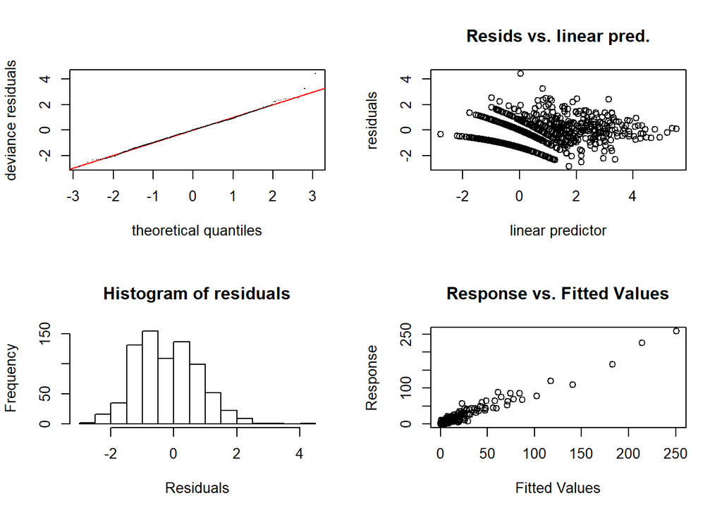

```
##
## Method: REML   Optimizer: outer newton
## full convergence after 14 iterations.
## Gradient range [-6.216734e-05,6.207856e-05]
## (score 1525.376 & scale 1).
## Hessian positive definite, eigenvalue range [3.197178e-05,34.36867].
## Model rank =  98 / 98
##
## Basis dimension (k) checking results. Low p-value (k-index<1) may
## indicate that k is too low, especially if edf is close to k'.
##
##                                   k'    edf k-index p-value
## s(x,y)                        29.000 12.768    0.78  <2e-16 ***
## s(year)                        2.000  0.976    0.99    0.86
## s(tot_pop)                     9.000  6.948    0.83  <2e-16 ***
## s(mean_house_inc)              9.000  5.966    0.81  <2e-16 ***
## s(pop_struggling_prop)         9.000  4.234    0.80  <2e-16 ***
## s(opioid_rate_avg)             9.000  4.099    0.96    0.61
## s(less_than_hs_ed)             9.000  2.491    0.80  <2e-16 ***
## s(alprazolam_per_65_and_over)  9.000  1.823    0.88  <2e-16 ***
## s(lorazepam_per_65_and_over)   9.000  5.560    0.94    0.34
## ---
## Signif. codes:  0 '***' 0.001 '**' 0.01 '*' 0.05 '.' 0.1 ' ' 1
```

```r
gam.check(full_model_sub3)
```

```r
concurvity(full_model_sub3)
```

```
##               para    s(x,y)    s(year) s(tot_pop) s(mean_house_inc)
## worst    0.7736603 0.8577695 0.06845374  0.9616412         0.9053414
## observed 0.7736603 0.6362238 0.06572076  0.8143707         0.8746232
## estimate 0.7736603 0.3936551 0.06239086  0.3635640         0.7332943
##          s(pop_struggling_prop) s(opioid_rate_avg) s(less_than_hs_ed)
## worst                 0.8909029          0.4342609          0.8851430
## observed              0.6691660          0.3491543          0.8051169
## estimate              0.8276068          0.2255786          0.8245865
##          s(alprazolam_per_65_and_over) s(lorazepam_per_65_and_over)
## worst                        0.8248783                    0.8267332
## observed                     0.7693651                    0.5176958
## estimate                     0.6006272                    0.6103246
```

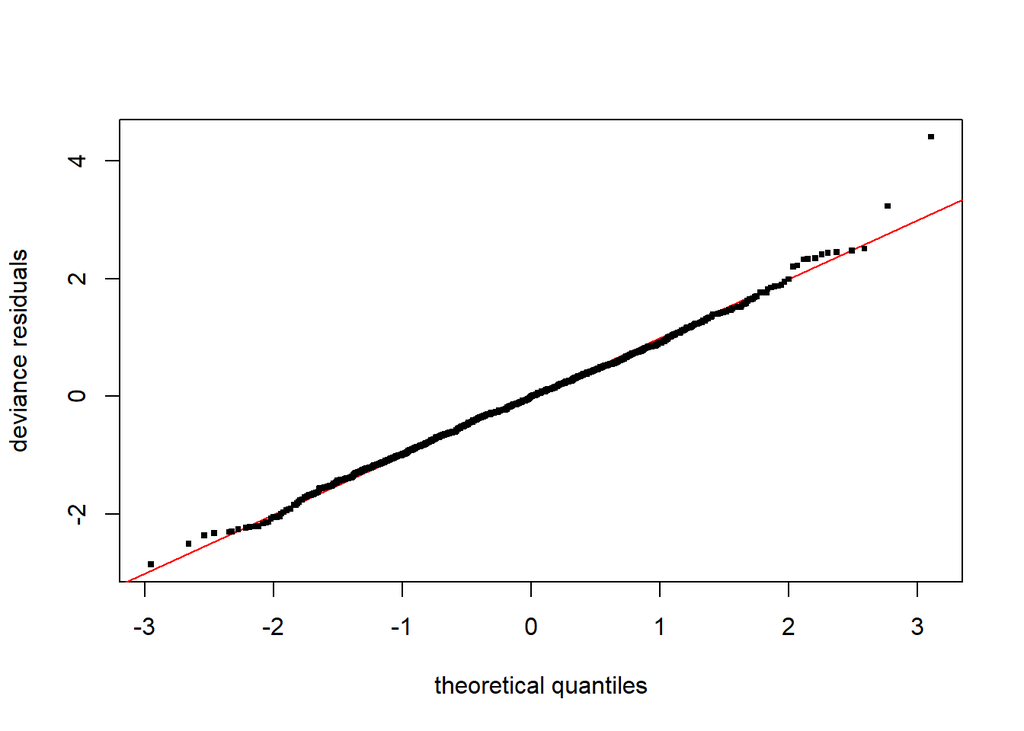

```r
qq.gam(full_model_sub3, cex = 4)
```

```r
# error on training
rmse(full_model_sub3, train_set)
```

```
## [1] 4.136449
```

```r
# error on validation
rmse(full_model_sub3, valid_set)
```

```
## [1] 8.505387
```

Notes:

GAM Summary: * urb_v_rururban not significant

GAM check: * still ignoring this mostly - alprazolam_per_65_and_over consistently significant, may need more basis functions?

Concurvity: * will continue to ignore total population concurvity, needs to be in the model * pop_struggling_prop, mean_house_inc, less_than_hs_ed still high

RMSE Error: * error on both training and validation are both slightly up, but that feature had to be removed because of high concurvity

Individual feature concurvity check:

- what does total population have high concurvity with?

```r
full_model_sub3_conc <- concurvity_df(full_model_sub3)
full_model_sub3_conc %>%
  select(feature, contains("tot_pop")) %>%
  arrange(desc(worst.s.tot_pop.))
```

```
## # A tibble: 10 x 2
##    feature                       worst.s.tot_pop.
##    <chr>                                    <dbl>
##  1 s(tot_pop)                               1
##  2 s(x,y)                                   0.503
##  3 s(less_than_hs_ed)                       0.444
##  4 s(pop_struggling_prop)                   0.263
##  5 s(alprazolam_per_65_and_over)            0.2
##  6 s(opioid_rate_avg)                       0.195
##  7 s(mean_house_inc)                        0.19
##  8 s(lorazepam_per_65_and_over)             0.155
##  9 s(year)                                  0.004
## 10 para                                     0
```

Sub4 - remove urban v rural - not informative/predictive

```r
full_model_sub4 <- gam(
    death_count_next_year ~ s(x,y) + s(year, k=3) + s(tot_pop) + s(mean_house_inc) + s(pop_struggling_prop) + town_status + s(opioid_rate_avg) + s(less_than_hs_ed) + s(alprazolam_per_65_and_over) + s(lorazepam_per_65_and_over),
    data = train_set, method = "REML", family = nb(), select = TRUE
    )
summary(full_model_sub4)
```

```
##
## Family: Negative Binomial(5.74)
## Link function: log
##
## Formula:
## death_count_next_year ~ s(x, y) + s(year, k = 3) + s(tot_pop) +
##     s(mean_house_inc) + s(pop_struggling_prop) + town_status +
##     s(opioid_rate_avg) + s(less_than_hs_ed) + s(alprazolam_per_65_and_over) +
##     s(lorazepam_per_65_and_over)
##
## Parametric coefficients:
##                      Estimate Std. Error z value Pr(>|z|)
## (Intercept)           0.63949    0.04641  13.780   <2e-16 ***
## town_statusshrunk     0.28560    0.18263   1.564   0.1179
## town_statusuncertain  0.41778    0.16275   2.567   0.0103 *
## ---
## Signif. codes:  0 '***' 0.001 '**' 0.01 '*' 0.05 '.' 0.1 ' ' 1
##
## Approximate significance of smooth terms:
##                                   edf Ref.df  Chi.sq  p-value
## s(x,y)                        11.3039     29 114.108  < 2e-16 ***
## s(year)                        0.9755      2  39.200 1.98e-10 ***
## s(tot_pop)                     7.1012      9 466.012  < 2e-16 ***
## s(mean_house_inc)              6.0088      9  62.906 1.37e-14 ***
## s(pop_struggling_prop)         4.5726      9  21.838 2.32e-05 ***
## s(opioid_rate_avg)             4.0747      9  22.359 3.42e-05 ***
## s(less_than_hs_ed)             2.3701      9  10.509 0.001436 **
## s(alprazolam_per_65_and_over)  1.6176      9   4.375 0.030169 *
## s(lorazepam_per_65_and_over)   2.0083      9   9.788 0.000806 ***
## ---
## Signif. codes:  0 '***' 0.001 '**' 0.01 '*' 0.05 '.' 0.1 ' ' 1
##
## R-sq.(adj) =  0.947   Deviance explained = 85.9%
## -REML = 1525.3  Scale est. = 1         n = 768
```

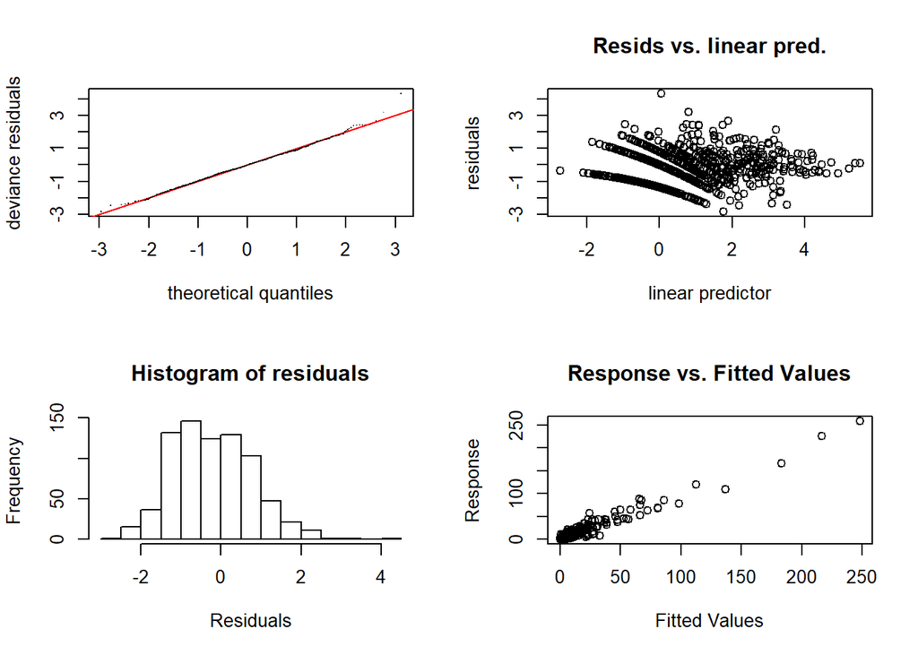

```
##
## Method: REML   Optimizer: outer newton
## full convergence after 15 iterations.
## Gradient range [-0.0001350537,0.0001486695]
## (score 1525.252 & scale 1).
## Hessian positive definite, eigenvalue range [5.310775e-05,39.71717].
## Model rank =  97 / 97
##
## Basis dimension (k) checking results. Low p-value (k-index<1) may
## indicate that k is too low, especially if edf is close to k'.
##
##                                   k'    edf k-index p-value
## s(x,y)                        29.000 11.304    0.77  <2e-16 ***
## s(year)                        2.000  0.976    0.99   0.825
## s(tot_pop)                     9.000  7.101    0.83  <2e-16 ***
## s(mean_house_inc)              9.000  6.009    0.80  <2e-16 ***
## s(pop_struggling_prop)         9.000  4.573    0.78  <2e-16 ***
## s(opioid_rate_avg)             9.000  4.075    0.95   0.450
## s(less_than_hs_ed)             9.000  2.370    0.79  <2e-16 ***
## s(alprazolam_per_65_and_over)  9.000  1.618    0.88   0.005 **
## s(lorazepam_per_65_and_over)   9.000  2.008    0.92   0.195
## ---
## Signif. codes:  0 '***' 0.001 '**' 0.01 '*' 0.05 '.' 0.1 ' ' 1
```

```r
gam.check(full_model_sub4)
```

```r
concurvity(full_model_sub4)
```

```
##               para    s(x,y)    s(year) s(tot_pop) s(mean_house_inc)
## worst    0.5039308 0.8577526 0.06822290  0.7717331         0.9052666
## observed 0.5039308 0.6319379 0.06548912  0.7533348         0.8754872
## estimate 0.5039308 0.3896337 0.06217524  0.3087187         0.7328897
##          s(pop_struggling_prop) s(opioid_rate_avg) s(less_than_hs_ed)
## worst                 0.8880721          0.4311798          0.8850331
## observed              0.6244032          0.3538625          0.7988786
## estimate              0.8261142          0.2250580          0.8238433
##          s(alprazolam_per_65_and_over) s(lorazepam_per_65_and_over)
## worst                        0.8246632                    0.8264992
## observed                     0.7713384                    0.7758717
## estimate                     0.5998403                    0.6098383
```

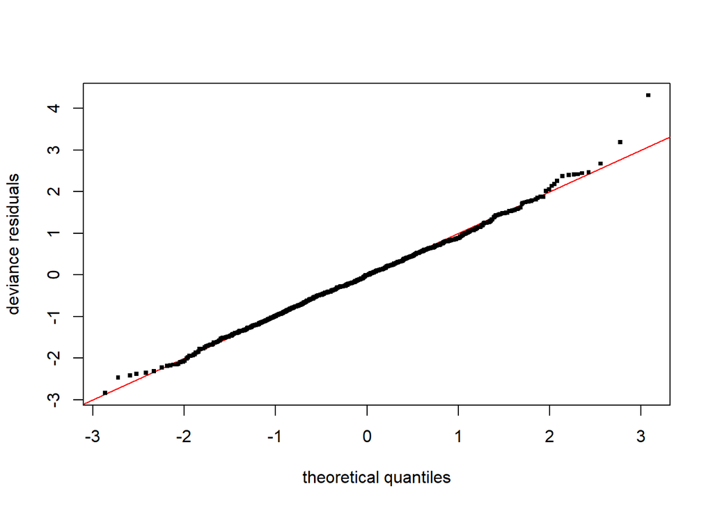

```r
qq.gam(full_model_sub4, cex = 4)
```

```r
# error on training
rmse(full_model_sub4, train_set)
```

```
## [1] 4.15251
```

```r
# error on validation
rmse(full_model_sub4, valid_set)
```

```
## [1] 7.803426
```

Notes:

GAM Summary: * all features statistically significant, will now focus on concurvity issues

GAM check: * still mostly ignoring this

Concurvity: * mean_house_inc, pop_struggling_prop, less_than_hs_ed still have overall worst-case concurvity estimates over the desired threshold of 0.84

RMSE Error: * train error slightly up * but validation error went down by quite a bit (relatively speaking)

Individual feature concurvity check:

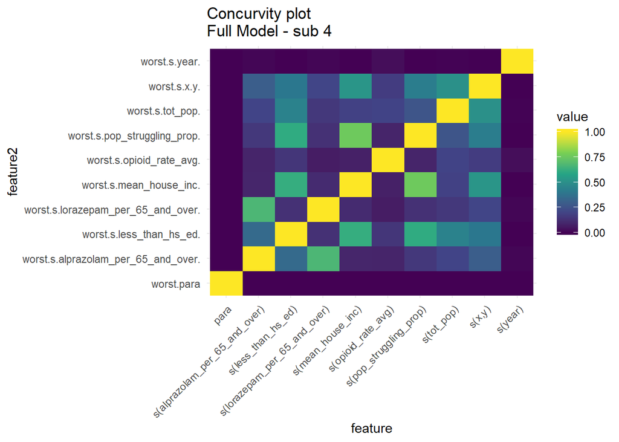

```r
full_model_sub4_conc <- concurvity_df(full_model_sub4)
full_model_sub4_conc %>%
  gather(key="feature2", value="value", -feature) %>%
  ggplot(aes(feature, feature2, fill=value)) +
  geom_raster() +
  scale_fill_viridis_c() +
  theme(axis.text.x = element_text(angle=45, hjust=1)) +
  ggtitle("Concurvity plot\nFull Model - sub 4")
```

- mean_house_inc, pop_struggling_prop, less_than_hs_ed seem to have relatively high concurvity with each other

Before moving on, try out another type of interaction term between x, y, and total population

```r
full_model_sub5 <- gam(
    death_count_next_year ~ s(x,y) + s(year, k=3) + s(tot_pop) + s(mean_house_inc) + s(pop_struggling_prop) + town_status + s(opioid_rate_avg) + s(less_than_hs_ed) + s(alprazolam_per_65_and_over) + s(lorazepam_per_65_and_over) + ti(x, y, tot_pop, d=c(2, 1)),
    data = train_set, method = "REML", family = nb(), select = TRUE
    )
summary(full_model_sub5)
```

```
##
## Family: Negative Binomial(7.333)
## Link function: log
##
## Formula:
## death_count_next_year ~ s(x, y) + s(year, k = 3) + s(tot_pop) +
##     s(mean_house_inc) + s(pop_struggling_prop) + town_status +
##     s(opioid_rate_avg) + s(less_than_hs_ed) + s(alprazolam_per_65_and_over) +
##     s(lorazepam_per_65_and_over) + ti(x, y, tot_pop, d = c(2,
##     1))
##
## Parametric coefficients:
##                      Estimate Std. Error z value Pr(>|z|)
## (Intercept)           0.64960    0.04821  13.475  < 2e-16 ***
## town_statusshrunk     0.24487    0.19915   1.230  0.21885
## town_statusuncertain  0.50455    0.16303   3.095  0.00197 **
## ---
## Signif. codes:  0 '***' 0.001 '**' 0.01 '*' 0.05 '.' 0.1 ' ' 1
##
## Approximate significance of smooth terms:
##                                   edf Ref.df  Chi.sq  p-value
## s(x,y)                        13.3946     29 130.218  < 2e-16 ***
## s(year)                        0.9777      2  43.197 2.46e-11 ***
## s(tot_pop)                     6.8455      9 380.716  < 2e-16 ***
## s(mean_house_inc)              6.0210      9  58.631 9.02e-14 ***
## s(pop_struggling_prop)         4.1465      9  23.567 2.70e-06 ***
## s(opioid_rate_avg)             4.0673      9  21.902 3.86e-05 ***
## s(less_than_hs_ed)             2.2845      9   9.943  0.00129 **
## s(alprazolam_per_65_and_over)  1.2676      9   2.584  0.07917 .
## s(lorazepam_per_65_and_over)   5.4821      9  28.679 1.10e-06 ***
## ti(x,y,tot_pop)                5.8002     94  25.865 1.22e-07 ***
## ---
## Signif. codes:  0 '***' 0.001 '**' 0.01 '*' 0.05 '.' 0.1 ' ' 1
##
## R-sq.(adj) =  0.948   Deviance explained = 87.5%
## -REML = 1517.5  Scale est. = 1         n = 768
```

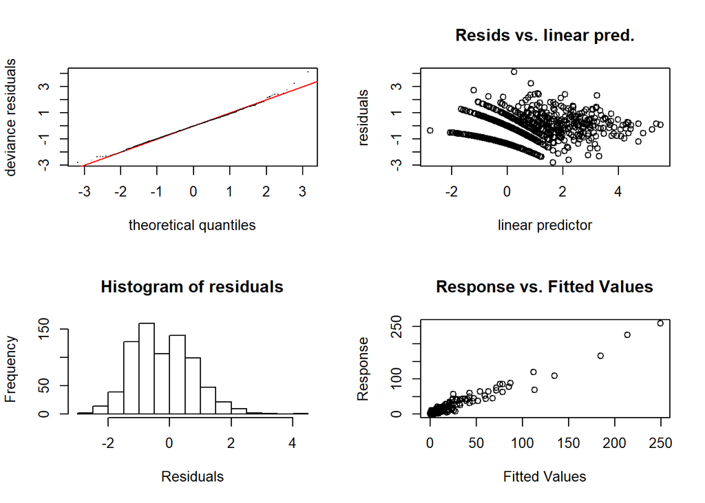

```
##
## Method: REML   Optimizer: outer newton
## full convergence after 13 iterations.
## Gradient range [-8.973565e-05,9.096696e-05]
## (score 1517.533 & scale 1).
## Hessian positive definite, eigenvalue range [3.105125e-05,30.92333].
## Model rank =  193 / 193
##
## Basis dimension (k) checking results. Low p-value (k-index<1) may
## indicate that k is too low, especially if edf is close to k'.
##
##                                   k'    edf k-index p-value
## s(x,y)                        29.000 13.395    0.81  <2e-16 ***
## s(year)                        2.000  0.978    0.98    0.80
## s(tot_pop)                     9.000  6.845    0.83  <2e-16 ***
## s(mean_house_inc)              9.000  6.021    0.82  <2e-16 ***
## s(pop_struggling_prop)         9.000  4.146    0.81  <2e-16 ***
## s(opioid_rate_avg)             9.000  4.067    0.98    0.72
## s(less_than_hs_ed)             9.000  2.284    0.83  <2e-16 ***
## s(alprazolam_per_65_and_over)  9.000  1.268    0.87    0.02 *
## s(lorazepam_per_65_and_over)   9.000  5.482    0.96    0.52
## ti(x,y,tot_pop)               96.000  5.800    0.80  <2e-16 ***
## ---
## Signif. codes:  0 '***' 0.001 '**' 0.01 '*' 0.05 '.' 0.1 ' ' 1
```

```r
gam.check(full_model_sub5)
```

```r
concurvity(full_model_sub5)
```

```
##               para    s(x,y)   s(year) s(tot_pop) s(mean_house_inc)
## worst    0.9999887 0.9999997 0.1165154  0.9999999         0.9713785
## observed 0.9999887 0.9833993 0.1136364  0.9931974         0.9388635
## estimate 0.9999887 0.9852910 0.1076091  0.9991458         0.8416002
##          s(pop_struggling_prop) s(opioid_rate_avg) s(less_than_hs_ed)
## worst                 0.9795099          0.6425545          0.9971383
## observed              0.8598854          0.5466956          0.9572914
## estimate              0.9067481          0.4522386          0.9510748
##          s(alprazolam_per_65_and_over) s(lorazepam_per_65_and_over)
## worst                        0.9636406                    0.9213780
## observed                     0.8890602                    0.7486827
## estimate                     0.7744816                    0.8119820
##          ti(x,y,tot_pop)
## worst          0.9999999
## observed       0.6082523
## estimate       0.6884261
```

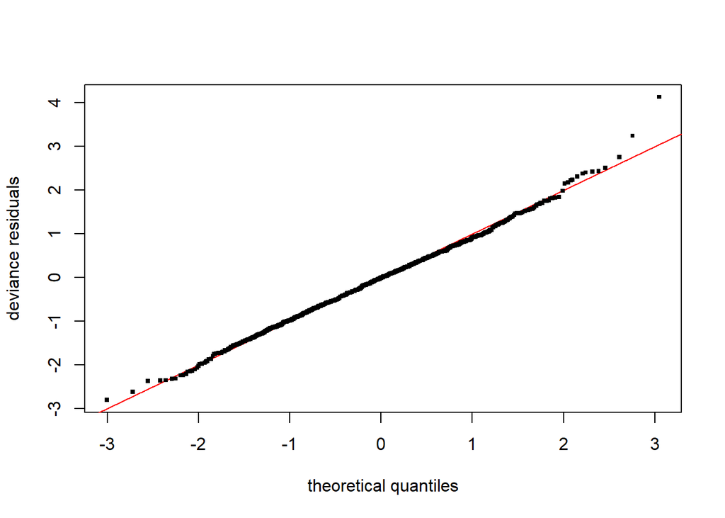

```r
qq.gam(full_model_sub5, cex = 4)
```

```r
# error on training
rmse(full_model_sub5, train_set)
```

```
## [1] 4.097621
```

```r
# error on validation
rmse(full_model_sub5, valid_set)
```

```
## [1] 9.342421
```

Notes:

- alprazolam_per_65_and_over now not significant
- Concurvities overall went way up again
- Error on validation went way up again too

Back pedal - take that out and go back to sub 4 - look at interaction between terms mean_house_inc, pop_struggling_prop, and less_than_hs_ed

```r
# mean income concurvity
full_model_sub4_conc %>%
  select(feature, contains("mean")) %>%
  arrange(desc(worst.s.mean_house_inc.))
```

```
## # A tibble: 10 x 2
##    feature                       worst.s.mean_house_inc.
##    <chr>                                           <dbl>
##  1 s(mean_house_inc)                               1
##  2 s(pop_struggling_prop)                          0.76
##  3 s(less_than_hs_ed)                              0.625
##  4 s(x,y)                                          0.52
##  5 s(tot_pop)                                      0.19
##  6 s(lorazepam_per_65_and_over)                    0.111
##  7 s(alprazolam_per_65_and_over)                   0.092
##  8 s(opioid_rate_avg)                              0.078
##  9 s(year)                                         0.001
## 10 para                                            0
```

```r
# hs education concurvity
full_model_sub4_conc %>%
  select(feature, contains("hs")) %>%
  arrange(desc(worst.s.less_than_hs_ed.))
```

```
## # A tibble: 10 x 2
##    feature                       worst.s.less_than_hs_ed.
##    <chr>                                            <dbl>
##  1 s(less_than_hs_ed)                               1
##  2 s(mean_house_inc)                                0.625
##  3 s(pop_struggling_prop)                           0.616
##  4 s(tot_pop)                                       0.444
##  5 s(x,y)                                           0.398
##  6 s(alprazolam_per_65_and_over)                    0.347
##  7 s(opioid_rate_avg)                               0.147
##  8 s(lorazepam_per_65_and_over)                     0.132
##  9 para                                             0
## 10 s(year)                                          0
```

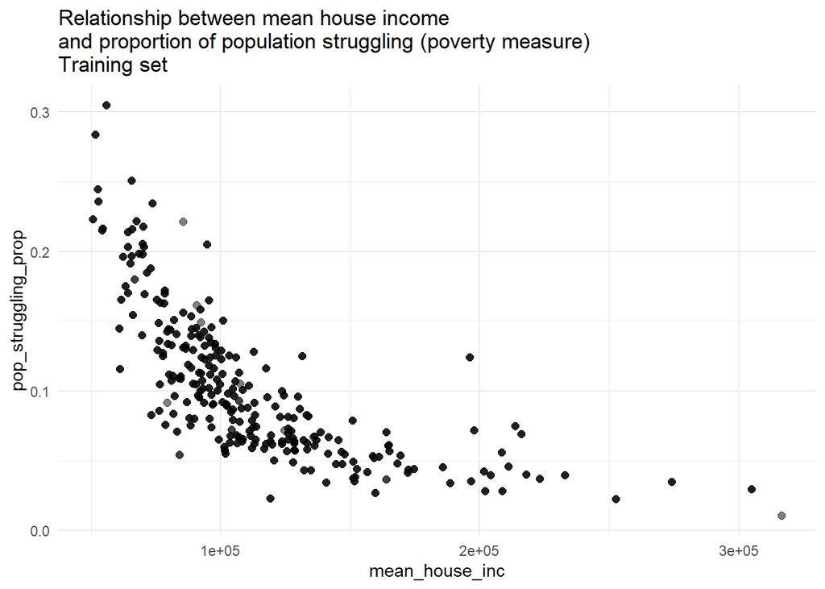

```r
train_set %>%
  ggplot(aes(mean_house_inc, pop_struggling_prop)) +
  geom_point(size = 2, alpha = 0.5) +
  ggtitle("Relationship between mean house income\nand proportion of population struggling (poverty measure)\nTraining set")
```

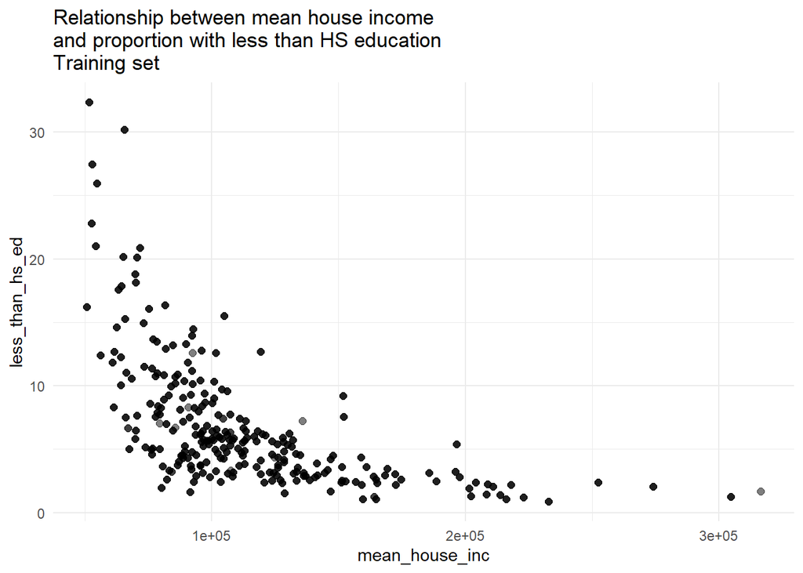

```r
train_set %>%
  ggplot(aes(mean_house_inc, less_than_hs_ed)) +
  geom_point(size = 2, alpha = 0.5) +
  ggtitle("Relationship between mean house income\nand proportion with less than HS education\nTraining set")
```

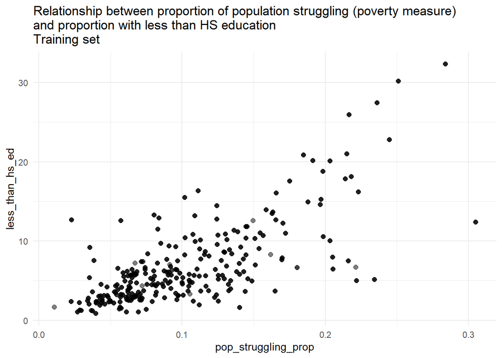

```r
train_set %>%
  ggplot(aes(pop_struggling_prop, less_than_hs_ed)) +
  geom_point(size = 2, alpha = 0.5) +
  ggtitle("Relationship between proportion of population struggling (poverty measure)\nand proportion with less than HS education\nTraining set")
```

```r
full_model_sub4_conc %>%
  select(feature, contains("tot_pop")) %>%
  arrange(desc(worst.s.tot_pop.))
```

```
## # A tibble: 10 x 2
##    feature                       worst.s.tot_pop.
##    <chr>                                    <dbl>
##  1 s(tot_pop)                               1
##  2 s(x,y)                                   0.503
##  3 s(less_than_hs_ed)                       0.444
##  4 s(pop_struggling_prop)                   0.263
##  5 s(alprazolam_per_65_and_over)            0.2
##  6 s(opioid_rate_avg)                       0.195
##  7 s(mean_house_inc)                        0.19
##  8 s(lorazepam_per_65_and_over)             0.155
##  9 s(year)                                  0.004
## 10 para                                     0
```

`less_than_hs_ed` has high concurvity with mean income and total population - try removing it

```r
full_model_sub6 <- gam(
    death_count_next_year ~ s(x,y) + s(year, k=3) + s(tot_pop) + s(mean_house_inc) + s(pop_struggling_prop) + town_status + s(opioid_rate_avg) + s(alprazolam_per_65_and_over) + s(lorazepam_per_65_and_over),
    data = train_set, method = "REML", family = nb(), select = TRUE
    )
summary(full_model_sub6)
```

```
##
## Family: Negative Binomial(5.36)
## Link function: log
##
## Formula:
## death_count_next_year ~ s(x, y) + s(year, k = 3) + s(tot_pop) +
##     s(mean_house_inc) + s(pop_struggling_prop) + town_status +
##     s(opioid_rate_avg) + s(alprazolam_per_65_and_over) + s(lorazepam_per_65_and_over)
##
## Parametric coefficients:
##                      Estimate Std. Error z value Pr(>|z|)
## (Intercept)           0.64194    0.04655  13.791  < 2e-16 ***
## town_statusshrunk     0.31074    0.18309   1.697  0.08966 .
## town_statusuncertain  0.48880    0.15977   3.059  0.00222 **
## ---
## Signif. codes:  0 '***' 0.001 '**' 0.01 '*' 0.05 '.' 0.1 ' ' 1
##
## Approximate significance of smooth terms:
##                                   edf Ref.df  Chi.sq  p-value
## s(x,y)                        11.2400     29 107.117  < 2e-16 ***
## s(year)                        0.9756      2  39.214 2.00e-10 ***
## s(tot_pop)                     7.1691      9 452.939  < 2e-16 ***
## s(mean_house_inc)              5.8383      9  59.327 1.66e-13 ***
## s(pop_struggling_prop)         4.8714      9  30.929 2.08e-07 ***
## s(opioid_rate_avg)             4.0424      9  24.096 1.32e-05 ***
## s(alprazolam_per_65_and_over)  1.4762      9   3.485 0.049442 *
## s(lorazepam_per_65_and_over)   1.8931      9   9.920 0.000519 ***
## ---
## Signif. codes:  0 '***' 0.001 '**' 0.01 '*' 0.05 '.' 0.1 ' ' 1
##
## R-sq.(adj) =  0.943   Deviance explained = 85.4%
## -REML = 1528.1  Scale est. = 1         n = 768
```

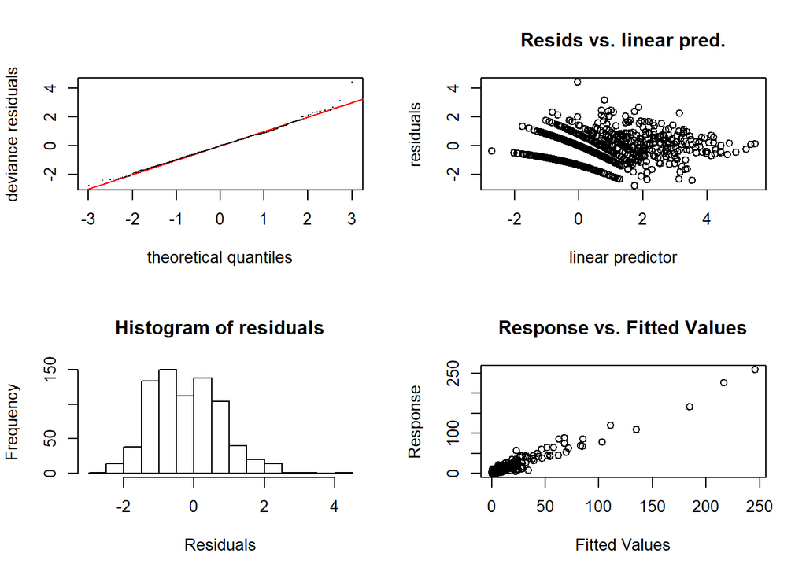

```
##
## Method: REML   Optimizer: outer newton
## full convergence after 16 iterations.
## Gradient range [-0.0003047746,0.000211597]
## (score 1528.079 & scale 1).
## Hessian positive definite, eigenvalue range [3.6593e-06,42.86653].
## Model rank =  88 / 88
##
## Basis dimension (k) checking results. Low p-value (k-index<1) may
## indicate that k is too low, especially if edf is close to k'.
##
##                                   k'    edf k-index p-value
## s(x,y)                        29.000 11.240    0.76  <2e-16 ***
## s(year)                        2.000  0.976    0.98    0.78
## s(tot_pop)                     9.000  7.169    0.83  <2e-16 ***
## s(mean_house_inc)              9.000  5.838    0.78  <2e-16 ***
## s(pop_struggling_prop)         9.000  4.871    0.77  <2e-16 ***
## s(opioid_rate_avg)             9.000  4.042    0.95    0.52
## s(alprazolam_per_65_and_over)  9.000  1.476    0.87  <2e-16 ***
## s(lorazepam_per_65_and_over)   9.000  1.893    0.92    0.19
## ---
## Signif. codes:  0 '***' 0.001 '**' 0.01 '*' 0.05 '.' 0.1 ' ' 1
```

```r
gam.check(full_model_sub6)
```

```r
concurvity(full_model_sub6)
```

```
##               para    s(x,y)    s(year) s(tot_pop) s(mean_house_inc)
## worst    0.4962181 0.8420705 0.06594953  0.7573593         0.8677297
## observed 0.4962181 0.5928009 0.06340784  0.7432102         0.8362984
## estimate 0.4962181 0.3435830 0.06018835  0.2610703         0.6746542
##          s(pop_struggling_prop) s(opioid_rate_avg)
## worst                 0.8612817          0.4163092
## observed              0.5153487          0.3400236
## estimate              0.7935510          0.2069167
##          s(alprazolam_per_65_and_over) s(lorazepam_per_65_and_over)
## worst                        0.8152271                    0.8203100
## observed                     0.7537780                    0.7760026
## estimate                     0.5688723                    0.5889704
```

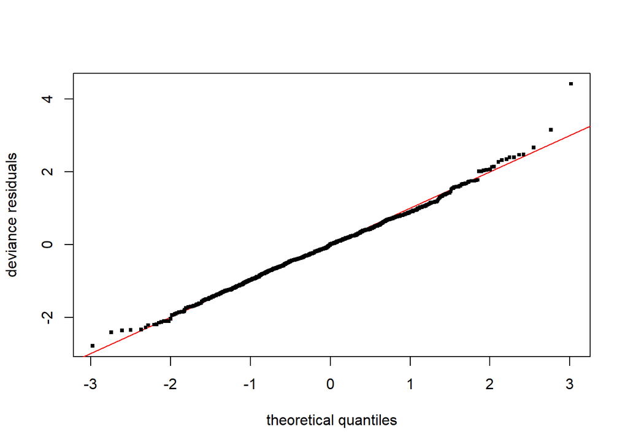

```r
qq.gam(full_model_sub6, cex = 4)
```

```r
# error on training
rmse(full_model_sub6, train_set)
```

```
## [1] 4.343633
```

```r
# error on validation
rmse(full_model_sub6, valid_set)
```

```
## [1] 7.939338
```

Notes:

GAM Summary: * alprazolam_per_65_and_over significant

GAM check: * maybe it’s time to try upping the k for some of these features?

Concurvity: * `mean_house_inc` and `pop_struggling_prop` still have high worst-case concurvity

Individual feature concurvity check:

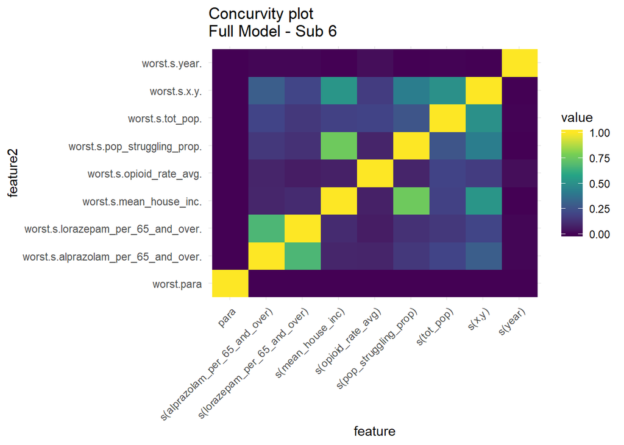

```r
full_model_sub6_conc <- concurvity_df(full_model_sub6)
full_model_sub6_conc %>%
  gather(key="feature2", value="value", -feature) %>%
  ggplot(aes(feature, feature2, fill=value)) +
  geom_raster() +
  scale_fill_viridis_c() +
  theme(axis.text.x = element_text(angle=45, hjust=1)) +
  ggtitle("Concurvity plot\nFull Model - Sub 6")
```

- `mean_house_inc` and `pop_struggling_prop` still have high worst-case concurvity with each other - need to pick one

Try giving higher k to terms first - not sure if that will increase or decrease concurvity

```r
full_model_sub7 <- gam(
    death_count_next_year ~ s(x,y) + s(year, k=3) + s(tot_pop, k = 12) + s(mean_house_inc, k = 12) + s(pop_struggling_prop, k =12) + town_status + s(opioid_rate_avg) + s(alprazolam_per_65_and_over, k = 12) + s(lorazepam_per_65_and_over),
    data = train_set, method = "REML", family = nb(), select = TRUE
    )
summary(full_model_sub7)
```

```
##
## Family: Negative Binomial(5.399)
## Link function: log
##
## Formula:
## death_count_next_year ~ s(x, y) + s(year, k = 3) + s(tot_pop,
##     k = 12) + s(mean_house_inc, k = 12) + s(pop_struggling_prop,
##     k = 12) + town_status + s(opioid_rate_avg) + s(alprazolam_per_65_and_over,
##     k = 12) + s(lorazepam_per_65_and_over)
##
## Parametric coefficients:
##                      Estimate Std. Error z value Pr(>|z|)
## (Intercept)           0.64223    0.04653  13.803  < 2e-16 ***
## town_statusshrunk     0.31460    0.18355   1.714  0.08653 .
## town_statusuncertain  0.49062    0.15990   3.068  0.00215 **
## ---
## Signif. codes:  0 '***' 0.001 '**' 0.01 '*' 0.05 '.' 0.1 ' ' 1
##
## Approximate significance of smooth terms:
##                                   edf Ref.df  Chi.sq  p-value
## s(x,y)                        11.3834     29 107.725  < 2e-16 ***
## s(year)                        0.9757      2  39.344 1.86e-10 ***
## s(tot_pop)                     7.4728     11 449.563  < 2e-16 ***
## s(mean_house_inc)              6.3136     11  61.241 7.86e-14 ***
## s(pop_struggling_prop)         5.1411     11  31.930 1.28e-07 ***
## s(opioid_rate_avg)             4.0363      9  23.856 1.47e-05 ***
## s(alprazolam_per_65_and_over)  1.4897     11   3.525  0.04839 *
## s(lorazepam_per_65_and_over)   1.8813      9   9.858  0.00052 ***
## ---
## Signif. codes:  0 '***' 0.001 '**' 0.01 '*' 0.05 '.' 0.1 ' ' 1
##
## R-sq.(adj) =  0.943   Deviance explained = 85.5%
## -REML =   1528  Scale est. = 1         n = 768
```

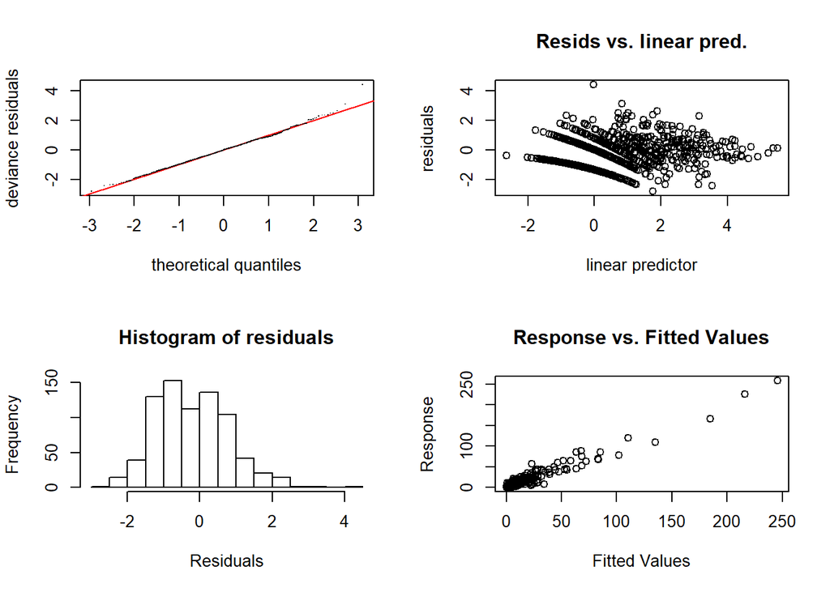

```
##
## Method: REML   Optimizer: outer newton
## full convergence after 16 iterations.
## Gradient range [-0.0002323157,6.30099e-05]
## (score 1528.032 & scale 1).
## Hessian positive definite, eigenvalue range [4.006753e-05,42.43597].
## Model rank =  96 / 96
##
## Basis dimension (k) checking results. Low p-value (k-index<1) may
## indicate that k is too low, especially if edf is close to k'.
##
##                                   k'    edf k-index p-value
## s(x,y)                        29.000 11.383    0.76  <2e-16 ***
## s(year)                        2.000  0.976    0.98   0.775
## s(tot_pop)                    11.000  7.473    0.83  <2e-16 ***
## s(mean_house_inc)             11.000  6.314    0.78  <2e-16 ***
## s(pop_struggling_prop)        11.000  5.141    0.77  <2e-16 ***
## s(opioid_rate_avg)             9.000  4.036    0.95   0.585
## s(alprazolam_per_65_and_over) 11.000  1.490    0.87   0.005 **
## s(lorazepam_per_65_and_over)   9.000  1.881    0.92   0.185
## ---
## Signif. codes:  0 '***' 0.001 '**' 0.01 '*' 0.05 '.' 0.1 ' ' 1
```

```r
gam.check(full_model_sub7)
```

```r
concurvity(full_model_sub7)
```

```
##               para    s(x,y)    s(year) s(tot_pop) s(mean_house_inc)
## worst    0.5070413 0.8600207 0.07174137  0.7725419         0.8734639
## observed 0.5070413 0.6116797 0.06853692  0.7494595         0.8381536
## estimate 0.5070413 0.3656083 0.06505505  0.2681268         0.6774689
##          s(pop_struggling_prop) s(opioid_rate_avg)
## worst                 0.8675852          0.4422212
## observed              0.5241710          0.3556635
## estimate              0.7903489          0.2269456
##          s(alprazolam_per_65_and_over) s(lorazepam_per_65_and_over)
## worst                        0.8228687                    0.8255067
## observed                     0.7552296                    0.7860109
## estimate                     0.5692190                    0.6037837
```

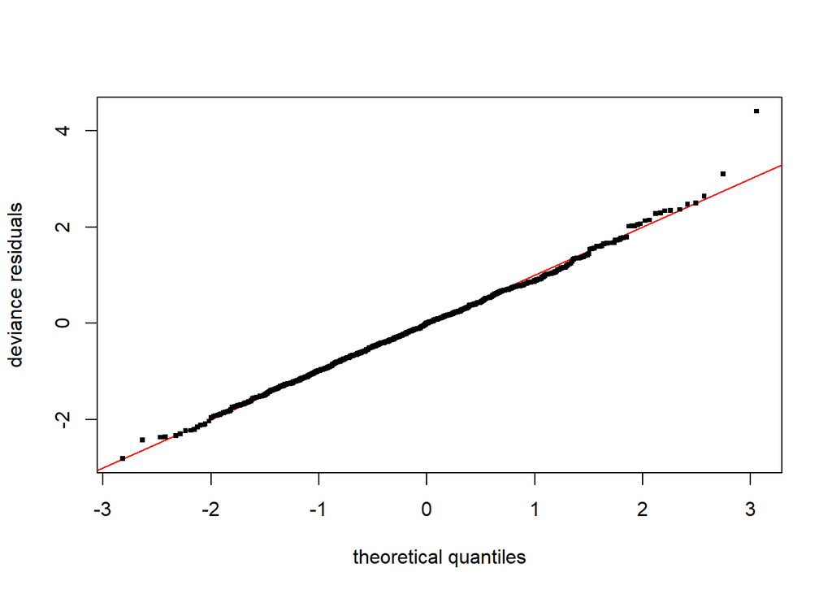

```r
qq.gam(full_model_sub7, cex = 4)
```

```r
# error on training
rmse(full_model_sub7, train_set)
```

```
## [1] 4.319936
```

```r
# error on validation
rmse(full_model_sub7, valid_set)
```

```
## [1] 7.892626
```

```r
rmse(full_model_sub6, valid_set)
```

```
## [1] 7.939338
```

Notes:

GAM Summary: * significance of predictors seems similar

GAM check: * although the k’s have been increased, the p-values still indicate that more are needed - not sure if it’s worth it (will likely lead to worse overfitting)

Concurvity: * Worst-case concurvity metrics didn’t change much between sub 6 and this iteration

RMSE Error: * Validation error went down slightly - is it worth it?

Likely not worth trying to change k at this point. Back pedal to previous iteration (sub 6) - check concurvities between mean income and population proportion that’s struggling

```r
full_model_sub6_conc %>%
  select(feature, contains("mean")) %>%
  arrange(desc(worst.s.mean_house_inc.))
```

```
## # A tibble: 9 x 2
##   feature                       worst.s.mean_house_inc.
##   <chr>                                           <dbl>
## 1 s(mean_house_inc)                               1
## 2 s(pop_struggling_prop)                          0.76
## 3 s(x,y)                                          0.52
## 4 s(tot_pop)                                      0.19
## 5 s(lorazepam_per_65_and_over)                    0.111
## 6 s(alprazolam_per_65_and_over)                   0.092
## 7 s(opioid_rate_avg)                              0.078
## 8 s(year)                                         0.001
## 9 para                                            0
```

```r
full_model_sub6_conc %>%
  select(feature, contains("pop_struggling_prop")) %>%
  arrange(desc(worst.s.pop_struggling_prop.))
```

```
## # A tibble: 9 x 2
##   feature                       worst.s.pop_struggling_prop.
##   <chr>                                                <dbl>
## 1 s(pop_struggling_prop)                               1
## 2 s(mean_house_inc)                                    0.76
## 3 s(x,y)                                               0.423
## 4 s(tot_pop)                                           0.263
## 5 s(alprazolam_per_65_and_over)                        0.156
## 6 s(lorazepam_per_65_and_over)                         0.132
## 7 s(opioid_rate_avg)                                   0.09
## 8 s(year)                                              0.001
## 9 para                                                 0
```

```r
sum(full_model_sub6_conc$worst.s.mean_house_inc.)
```

```
## [1] 2.752
```

```r
sum(full_model_sub6_conc$worst.s.pop_struggling_prop.)
```

```
## [1] 2.825
```

```r
summary(full_model_sub6)
```

```
##
## Family: Negative Binomial(5.36)
## Link function: log
##
## Formula:
## death_count_next_year ~ s(x, y) + s(year, k = 3) + s(tot_pop) +
##     s(mean_house_inc) + s(pop_struggling_prop) + town_status +
##     s(opioid_rate_avg) + s(alprazolam_per_65_and_over) + s(lorazepam_per_65_and_over)
##
## Parametric coefficients:
##                      Estimate Std. Error z value Pr(>|z|)
## (Intercept)           0.64194    0.04655  13.791  < 2e-16 ***
## town_statusshrunk     0.31074    0.18309   1.697  0.08966 .
## town_statusuncertain  0.48880    0.15977   3.059  0.00222 **
## ---
## Signif. codes:  0 '***' 0.001 '**' 0.01 '*' 0.05 '.' 0.1 ' ' 1
##
## Approximate significance of smooth terms:
##                                   edf Ref.df  Chi.sq  p-value
## s(x,y)                        11.2400     29 107.117  < 2e-16 ***
## s(year)                        0.9756      2  39.214 2.00e-10 ***
## s(tot_pop)                     7.1691      9 452.939  < 2e-16 ***
## s(mean_house_inc)              5.8383      9  59.327 1.66e-13 ***
## s(pop_struggling_prop)         4.8714      9  30.929 2.08e-07 ***
## s(opioid_rate_avg)             4.0424      9  24.096 1.32e-05 ***
## s(alprazolam_per_65_and_over)  1.4762      9   3.485 0.049442 *
## s(lorazepam_per_65_and_over)   1.8931      9   9.920 0.000519 ***
## ---
## Signif. codes:  0 '***' 0.001 '**' 0.01 '*' 0.05 '.' 0.1 ' ' 1
##
## R-sq.(adj) =  0.943   Deviance explained = 85.4%
## -REML = 1528.1  Scale est. = 1         n = 768
```

- The two features are pretty similar, not sure which to take out

Try sub 6, but take out alprazolam - does it make a diffrence?

```r
full_model_sub8 <- gam(
    death_count_next_year ~ s(x,y) + s(year, k=3) + s(tot_pop) + s(mean_house_inc) + s(pop_struggling_prop) + town_status + s(opioid_rate_avg) + s(lorazepam_per_65_and_over),
    data = train_set, method = "REML", family = nb(), select = TRUE
    )
summary(full_model_sub8)
```

```
##
## Family: Negative Binomial(5.237)
## Link function: log
##
## Formula:
## death_count_next_year ~ s(x, y) + s(year, k = 3) + s(tot_pop) +
##     s(mean_house_inc) + s(pop_struggling_prop) + town_status +
##     s(opioid_rate_avg) + s(lorazepam_per_65_and_over)
##
## Parametric coefficients:
##                      Estimate Std. Error z value Pr(>|z|)
## (Intercept)           0.64037    0.04671  13.711  < 2e-16 ***
## town_statusshrunk     0.31701    0.18441   1.719  0.08560 .
## town_statusuncertain  0.48496    0.16058   3.020  0.00253 **
## ---
## Signif. codes:  0 '***' 0.001 '**' 0.01 '*' 0.05 '.' 0.1 ' ' 1
##
## Approximate significance of smooth terms:
##                                  edf Ref.df Chi.sq  p-value
## s(x,y)                       11.3948     29 119.44  < 2e-16 ***
## s(year)                       0.9762      2  39.51 1.73e-10 ***
## s(tot_pop)                    7.1486      9 441.83  < 2e-16 ***
## s(mean_house_inc)             5.7550      9  60.57 6.90e-14 ***
## s(pop_struggling_prop)        4.8583      9  30.46 2.77e-07 ***
## s(opioid_rate_avg)            4.0973      9  25.66 6.10e-06 ***
## s(lorazepam_per_65_and_over)  2.3891      9  33.66 1.92e-09 ***
## ---
## Signif. codes:  0 '***' 0.001 '**' 0.01 '*' 0.05 '.' 0.1 ' ' 1
##
## R-sq.(adj) =  0.943   Deviance explained = 85.3%
## -REML = 1528.5  Scale est. = 1         n = 768
```

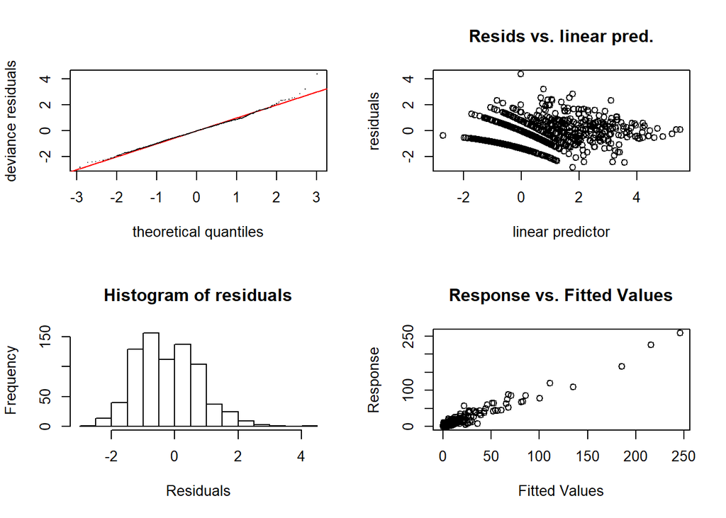

```
##
## Method: REML   Optimizer: outer newton
## full convergence after 14 iterations.
## Gradient range [-0.0009663817,0.0008665777]
## (score 1528.543 & scale 1).
## Hessian positive definite, eigenvalue range [3.098642e-05,44.8221].
## Model rank =  79 / 79
##
## Basis dimension (k) checking results. Low p-value (k-index<1) may
## indicate that k is too low, especially if edf is close to k'.
##
##                                  k'    edf k-index p-value
## s(x,y)                       29.000 11.395    0.76  <2e-16 ***
## s(year)                       2.000  0.976    0.98    0.77
## s(tot_pop)                    9.000  7.149    0.83  <2e-16 ***
## s(mean_house_inc)             9.000  5.755    0.78  <2e-16 ***
## s(pop_struggling_prop)        9.000  4.858    0.77  <2e-16 ***
## s(opioid_rate_avg)            9.000  4.097    0.96    0.52
## s(lorazepam_per_65_and_over)  9.000  2.389    0.93    0.18
## ---
## Signif. codes:  0 '***' 0.001 '**' 0.01 '*' 0.05 '.' 0.1 ' ' 1
```

```r
gam.check(full_model_sub8)
```

```r
concurvity(full_model_sub8)
```

```
##               para    s(x,y)    s(year) s(tot_pop) s(mean_house_inc)
## worst    0.4940628 0.8386801 0.05445013  0.7538392         0.8662788
## observed 0.4940628 0.5574164 0.05213669  0.7378813         0.8351894
## estimate 0.4940628 0.3022811 0.04951773  0.2480299         0.6674383
##          s(pop_struggling_prop) s(opioid_rate_avg)
## worst                 0.8597083          0.4080913
## observed              0.4800726          0.3258715
## estimate              0.7897739          0.1753102
##          s(lorazepam_per_65_and_over)
## worst                       0.3791483
## observed                    0.3490867
## estimate                    0.2604850
```

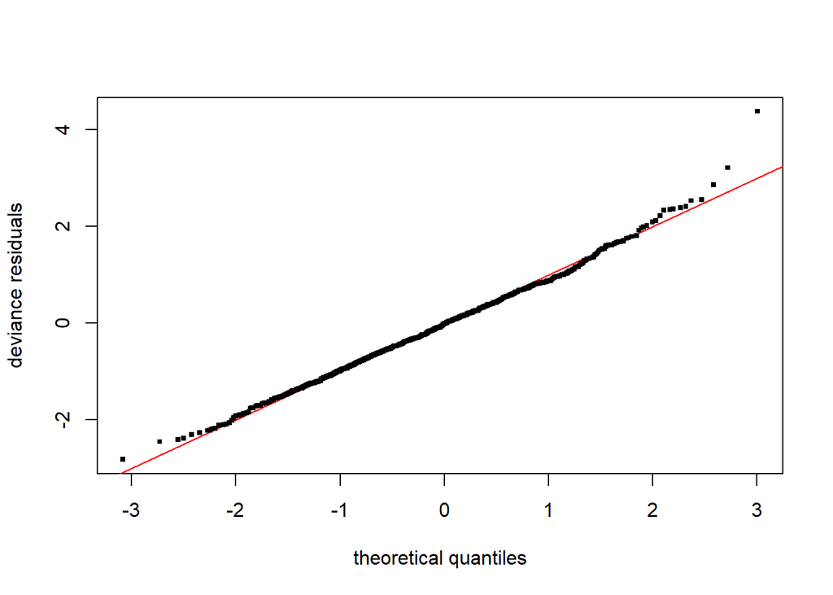

```r
qq.gam(full_model_sub8, cex = 4)
```

```r
# error on training
rmse(full_model_sub8, train_set)
```

```
## [1] 4.317482
```

```r
# error on validation
rmse(full_model_sub8, valid_set)
```

```
## [1] 7.817127
```

```r
rmse(full_model_sub6, valid_set)
```

```
## [1] 7.939338
```

Notes:

GAM check: * Not much has changed

Concurvity: * Wost-case concurvity of `lorazepam_per_65_and_over` with the model has gone way down, not surpsing since it had a strong relationship with alprazolam feature